# tidymodels: Hyperparameter Tuning with mlr3 and Tidymodels

Guido

2023-04-16

# Typical (but incomplete) Topics in Machine Learning

- Which algos –> `mlr3tuningspaces`: sets of different algos with predefined hyperparameters
- Hyperparameter: optimales Set –> Hyperparameter Tuning
- Geschwindigkeit, gerade bei Hyperparameter Tuning
- –> Early Stopping Policies, `terminator`
- Monitoring during optimization process
- Memory management –> `store_models = FALSE` –> rerun with identified hyperparameters
- CPU Usage, Architecture
- Select a final model and store trained models
- Deployment
- Pipelines –> Intergrate the whole / parts of the process incl. preprocessing

# Packages

**mlr3**: Overview: https://mlr3.mlr-org.com/  
Please note: Fastest way is to install `mlr3verse`. It will install (almost) all available packages  
**tidymodels**: Overview: https://www.tidymodels.org/packages/

```r
# packages Hyperparameter-Tuning
library(mlr3verse)    # load this package to get almost everything
library(tidymodels)   # load this package to get almost everything
library(paradox)      # to_tune()
library(fastDummies)  # Dummy coding
```

# Data

Data prepared by Oliver

```r
data_url <- "https://raw.githubusercontent.com/staehlo/mlr3_and_tidymodels/main/example_data_set.csv"
loans <- read.csv2(file = data_url, header = TRUE, sep = ",", dec=".")
str(loans)
```

```
## 'data.frame':    39786 obs. of  7 variables:
##  $ int_rate      : num  10.6 15.3 16 13.5 12.7 ...
##  $ loan_amnt     : int  5000 2500 2400 10000 3000 5000 7000 3000 5600 5375 ...
##  $ term          : int  36 60 36 36 60 36 60 36 60 60 ...
##  $ grade         : chr  "B" "C" "C" "C" ...
##  $ home_ownership: chr  "RENT" "RENT" "RENT" "RENT" ...
##  $ annual_inc    : num  24000 30000 12252 49200 80000 ...
##  $ purpose       : chr  "credit_card" "car" "small_business" "other" ...
```

# Data Preparation

Please note: in mlr3 in hyperparameter tuning, factors are currently not supported!

```r
# Dummy coding
#  1st dummy is contrast
loans <- fastDummies::dummy_cols(.data = loans, select_columns = c("home_ownership", "purpose"), remove_first_dummy = TRUE)
head(loans)
```

```
##   int_rate loan_amnt term grade home_ownership annual_inc        purpose
## 1    10.65      5000   36     B           RENT      24000    credit_card
## 2    15.27      2500   60     C           RENT      30000            car
## 3    15.96      2400   36     C           RENT      12252 small_business
## 4    13.49     10000   36     C           RENT      49200          other
## 5    12.69      3000   60     B           RENT      80000          other
## 6     7.90      5000   36     A           RENT      36000        wedding
##   home_ownership_NONE home_ownership_OTHER home_ownership_OWN
## 1                   0                    0                  0
## 2                   0                    0                  0
## 3                   0                    0                  0
## 4                   0                    0                  0
## 5                   0                    0                  0
## 6                   0                    0                  0
##   home_ownership_RENT purpose_credit_card purpose_debt_consolidation
```

[output cut: 34 more lines]

```r
# factors are only weakly supported in mlr3
#loans$home_ownership <- as.factor(loans$home_ownership)
#loans$purpose <- as.factor(loans$purpose)

# convert grade to numeric:
loans$numeric_grade <- match(loans$grade, LETTERS)
str(loans)
```

```
## 'data.frame':    39786 obs. of  25 variables:
##  $ int_rate                  : num  10.6 15.3 16 13.5 12.7 ...
##  $ loan_amnt                 : int  5000 2500 2400 10000 3000 5000 7000 3000 5600 5375 ...
##  $ term                      : int  36 60 36 36 60 36 60 36 60 60 ...
##  $ grade                     : chr  "B" "C" "C" "C" ...
##  $ home_ownership            : chr  "RENT" "RENT" "RENT" "RENT" ...
##  $ annual_inc                : num  24000 30000 12252 49200 80000 ...
##  $ purpose                   : chr  "credit_card" "car" "small_business" "other" ...
##  $ home_ownership_NONE       : int  0 0 0 0 0 0 0 0 0 0 ...
##  $ home_ownership_OTHER      : int  0 0 0 0 0 0 0 0 0 0 ...
##  $ home_ownership_OWN        : int  0 0 0 0 0 0 0 0 1 0 ...
##  $ home_ownership_RENT       : int  1 1 1 1 1 1 1 1 0 1 ...
##  $ purpose_credit_card       : int  1 0 0 0 0 0 0 0 0 0 ...
##  $ purpose_debt_consolidation: int  0 0 0 0 0 0 1 0 0 0 ...
##  $ purpose_educational       : int  0 0 0 0 0 0 0 0 0 0 ...
##  $ purpose_home_improvement  : int  0 0 0 0 0 0 0 0 0 0 ...
##  $ purpose_house             : int  0 0 0 0 0 0 0 0 0 0 ...
##  $ purpose_major_purchase    : int  0 0 0 0 0 0 0 0 0 0 ...
##  $ purpose_medical           : int  0 0 0 0 0 0 0 0 0 0 ...
##  $ purpose_moving            : int  0 0 0 0 0 0 0 0 0 0 ...
##  $ purpose_other             : int  0 0 0 1 1 0 0 0 0 1 ...
##  $ purpose_renewable_energy  : int  0 0 0 0 0 0 0 0 0 0 ...
##  $ purpose_small_business    : int  0 0 1 0 0 0 0 0 1 0 ...
##  $ purpose_vacation          : int  0 0 0 0 0 0 0 0 0 0 ...
##  $ purpose_wedding           : int  0 0 0 0 0 1 0 0 0 0 ...
##  $ numeric_grade             : int  2 3 3 3 2 1 3 5 6 2 ...
```

# Regression: Hyperparameter Tuning using mlr3 and Tidymodels to identify the best model set

- `loans` dataset (dim: 39786 x 7)
- Target variable is `int_rate`
- Target variable is measurement level `scale`

# Core Question Today: How to find the optimal set of hyperparameter?

# Hyperparameter Tuning with `mlr3`

Developed by Michel Lang et al., very vital and experienced team; - mlr3 is OOP-based –> `R6`; - mlr universe developed along several packages (see below)

**Core:** `mlr3tuning` package –> https://mlr3tuning.mlr-org.com/

- Package `bbotk` –> Black Box Optimization Toolkit
- Package `paradox` –> Define and Work with Parameter Spaces for Complex Algorithms

**Book-Chapter:** https://mlr3book.mlr-org.com/optimization.html

**mlr3 Cheat Sheet:** `mlr3 Hyperparameter Tuning Cheat Sheet:` https://cheatsheets.mlr-org.com/mlr3tuning.pdf

**Build-in Learners**

```r
# available learner in class learners
mlr_learners
```

```
## <DictionaryLearner> with 46 stored values
## Keys: classif.cv_glmnet, classif.debug, classif.featureless,
##   classif.glmnet, classif.kknn, classif.lda, classif.log_reg,
##   classif.multinom, classif.naive_bayes, classif.nnet, classif.qda,
##   classif.ranger, classif.rpart, classif.svm, classif.xgboost,
##   clust.agnes, clust.ap, clust.cmeans, clust.cobweb, clust.dbscan,
##   clust.diana, clust.em, clust.fanny, clust.featureless, clust.ff,
##   clust.hclust, clust.kkmeans, clust.kmeans, clust.MBatchKMeans,
##   clust.mclust, clust.meanshift, clust.pam, clust.SimpleKMeans,
##   clust.xmeans, regr.cv_glmnet, regr.debug, regr.featureless,
##   regr.glmnet, regr.kknn, regr.km, regr.lm, regr.nnet, regr.ranger,
##   regr.rpart, regr.svm, regr.xgboost
```

# Hyperparameter Tuning with `Tidymodels`

Formerly known as `caret` package. Supports the `tidyverse`

## mlr3: Prevent Overfitting

With mlr3, we can use `rsmp()` to specify a classical hold-out approach or - more convient - use a resampling strategy during the tuning process, typically a cross-validation approach.

To perform a classical hold-out approach, in other word, to split the data into a `training` and a `test` set, simply use the `sample()` function provided by base-R:

```r
# Get the number of cases
NumberOfCases <- nrow(loans)
# sample: generate a set of train IDs
TrainIDs <- base::sample(x = 1:NumberOfCases, size = NumberOfCases * 0.8, replace = FALSE)
length(TrainIDs)
```

```
## [1] 31828
```

```r
# Split the data
loansTrain <- loans[TrainIDs,]
loansTest <- loans[-TrainIDs,] # select cases by a negative integer
```

Both data.frames, `loansTrain` and `loansTest` can now be used in `mlr3`.

## Tidymodels: Prevent Overfitting

`Tidymodels` provides the functions `initial_split`, `training()` and `testing()` to perform the task.

```r
set.seed(123)
loans_split <- initial_split(loans %>% select(-grade, -purpose, -home_ownership))
loans_train <- training(loans_split)
loans_test  <- testing(loans_split)
head(loans_train)
```

```
##       int_rate loan_amnt term annual_inc home_ownership_NONE
## 2986     11.71      7200   36      30000                   0
## 29925    13.11     10000   36      32000                   0
## 29710    17.19      8000   60      79800                   0
## 37529    12.84     10000   36      40000                   0
## 2757     23.52     30000   60     110000                   0
## 38938    10.39     12000   36      45900                   0
##       home_ownership_OTHER home_ownership_OWN home_ownership_RENT
## 2986                     0                  0                   1
## 29925                    0                  0                   1
## 29710                    0                  1                   0
## 37529                    0                  0                   1
## 2757                     0                  0                   1
## 38938                    0                  0                   1
##       purpose_credit_card purpose_debt_consolidation purpose_educational
```

[output cut: 27 more lines]

# Predicting using Decision Tree Models

**Explore which** decision tree hyperparameter can be tuned.

- Explore the reference docs or
- Use the `base::args()` function to see which parsnip object arguments are available and the `parsnip::decision_tree` function (Tidymodels)

```r
# tidymodels: parsnip() with args()
base::args(parsnip::decision_tree)
```

```
## function (mode = "unknown", engine = "rpart", cost_complexity = NULL,
##     tree_depth = NULL, min_n = NULL)
## NULL
```

Three **Hyperparameters**:

- the `complexity parameter` (which we call cost_complexity in tidymodels) for the tree, and
- the `maximum tree_depth` parameter
- the `min_n` parameter

**`cost_complexity`:**  
Tuning the value of `cost_complexity` helps by pruning back our tree: It adds a cost, or penalty, to error rates of more complex trees; a cost closer to zero decreases the number tree nodes pruned and is more likely to result in an overfit tree. However, a high cost increases the number of tree nodes pruned and can result in the opposite problem — an underfit tree.

**`tree_depth`:**  
Tuning `tree_depth`, on the other hand, helps by stopping our tree from growing after it reaches a certain depth.

**`min_n`:** Number of cases in a node.

## Explore Model Arguments

Link: https://www.tidymodels.org/find/parsnip/#model-args

# mlr3: Specify a learner

```r
# Fast, but no hyperparameter tuning...
learner <- lrn("regr.rpart")
learner
```

```
## <LearnerRegrRpart:regr.rpart>: Regression Tree
## * Model: -
## * Parameters: xval=0
## * Packages: mlr3, rpart
## * Predict Type: response
## * Feature types: logical, integer, numeric, factor, ordered
## * Properties: importance, missings, selected_features, weights
```

Available Hyperparameter:

```r
learner$param_set$ids()
```

```
##  [1] "cp"             "keep_model"     "maxcompete"     "maxdepth"
##  [5] "maxsurrogate"   "minbucket"      "minsplit"       "surrogatestyle"
##  [9] "usesurrogate"   "xval"
```

**Metadata** of a learner: - `$feature_types`: the type of features the learner can handle. - `$packages`: the packages required to be installed to use the learner. - `$properties`: special properties the model can handle, for example the “missings” properties means a model can handle missing data, and “importance” means it can compute the relative importance of each feature. - `$predict_types`: the types of prediction that the model can make - `$param_set`: the set of available hyperparameters

**Setting up range of hyperparameters for: `cp` and `maxdepth`**

Please note: Use `learner$param_set` to get information to set up more hyperparameters

```r
# with hyperparameter tuning
learner <- mlr3::lrn("regr.rpart",
                    cp       = paradox::to_tune(0.001,  1, logscale = FALSE),
                    maxdepth = paradox::to_tune(1.   , 10, logscale = FALSE)
                    #, # max up to 30
                    #minsplit = paradox::to_tune(1    , 30, logscale = FALSE)
                    )
# print hyperparameters with tuning information
learner$param_set
```

```
## <ParamSet>
##                 id    class lower upper nlevels        default
##  1:             cp ParamDbl     0     1     Inf           0.01
##  2:     keep_model ParamLgl    NA    NA       2          FALSE
##  3:     maxcompete ParamInt     0   Inf     Inf              4
##  4:       maxdepth ParamInt     1    30      30             30
##  5:   maxsurrogate ParamInt     0   Inf     Inf              5
##  6:      minbucket ParamInt     1   Inf     Inf <NoDefault[3]>
##  7:       minsplit ParamInt     1   Inf     Inf             20
##  8: surrogatestyle ParamInt     0     1       2              0
##  9:   usesurrogate ParamInt     0     2       3              2
## 10:           xval ParamInt     0   Inf     Inf             10
##                   value
##  1: <RangeTuneToken[2]>
##  2:
##  3:
##  4: <RangeTuneToken[2]>
##  5:
##  6:
##  7:
##  8:
##  9:
## 10:                   0
```

One can use `learner$param_set$set_values()` to change a learners configuration.

# Tidymodels: Specify a learner

Tuning will be conducted using the `tune()` functions instead of setting concrete parameters. `tune()` acts like a placeholder.

```r
tune_spec <-
    decision_tree(
      tree_depth = tune(),
      cost_complexity = tune()) %>%
  # This model can be used for classification or regression, so set mode
  set_mode("regression") %>%
  set_engine("rpart")
tune_spec
```

```
## Decision Tree Model Specification (regression)
##
## Main Arguments:
##   cost_complexity = tune()
##   tree_depth = tune()
##
## Computational engine: rpart
```

# mlr3: Specify a Task

```r
# set up a task
#task <- TaskClassif$new(id = "lendingClub", loans, target = "term")
task <- as_task_regr(loans_train, target = "int_rate")
# some attributes etc.
task$nrow
```

```
## [1] 29839
```

```r
task$ncol
```

```
## [1] 22
```

```r
task$feature_names
```

```
##  [1] "annual_inc"                 "home_ownership_NONE"
##  [3] "home_ownership_OTHER"       "home_ownership_OWN"
##  [5] "home_ownership_RENT"        "loan_amnt"
##  [7] "numeric_grade"              "purpose_credit_card"
##  [9] "purpose_debt_consolidation" "purpose_educational"
## [11] "purpose_home_improvement"   "purpose_house"
## [13] "purpose_major_purchase"     "purpose_medical"
## [15] "purpose_moving"             "purpose_other"
## [17] "purpose_renewable_energy"   "purpose_small_business"
## [19] "purpose_vacation"           "purpose_wedding"
## [21] "term"
```

```r
task$formula()
```

```
## int_rate ~ .
## NULL
```

```r
# de-select "grade" - will used the numerical one
task$select(setdiff(task$feature_names, c("grade", "purpose", "home_ownership")))
```

# mlr3: Resampling

Web: https://mlr3book.mlr-org.com/performance.html#sec-resampling

```r
# features and targets - any partition roles? --> stratum
task$col_roles
```

```
## $feature
##  [1] "annual_inc"                 "home_ownership_NONE"
##  [3] "home_ownership_OTHER"       "home_ownership_OWN"
##  [5] "home_ownership_RENT"        "loan_amnt"
##  [7] "numeric_grade"              "purpose_credit_card"
##  [9] "purpose_debt_consolidation" "purpose_educational"
## [11] "purpose_home_improvement"   "purpose_house"
## [13] "purpose_major_purchase"     "purpose_medical"
## [15] "purpose_moving"             "purpose_other"
## [17] "purpose_renewable_energy"   "purpose_small_business"
## [19] "purpose_vacation"           "purpose_wedding"
## [21] "term"
##
## $target
## [1] "int_rate"
##
## $name
## character(0)
##
## $order
## character(0)
##
## $stratum
## character(0)
##
## $group
## character(0)
##
## $weight
## character(0)
```

```r
# set stratum with respect to target variable: int_rates
#task$col_roles$stratum <- "int_rate"
#task$strata
```

*Classical* **Holdout Resampling** (later combined with cross validation)

Steps: - Construction: defines how the data spliiting process will be performed when running the resampling strategy: it does not yet contain a concrete set of train-test splits - Instantiation: Generate the train-test splits

```r
# Construction
resampling <- rsmp("holdout", ratio = 0.7)
print(resampling)
```

```
## <ResamplingHoldout>: Holdout
## * Iterations: 1
## * Instantiated: FALSE
## * Parameters: ratio=0.7
```

```r
# Change to .75
resampling$param_set$values <- list(ratio = 0.75)
resampling$param_set$values
```

```
## $ratio
## [1] 0.75
```

```r
# Instantiation
resampling$instantiate(task)
train_ids <- resampling$train_set(1)
str(train_ids)
```

```
##  int [1:22379] 2 3 4 5 6 8 10 11 12 14 ...
```

```r
test_ids <- resampling$test_set(1)
str(test_ids)
```

```
##  int [1:7460] 1 7 9 13 15 18 20 23 26 27 ...
```

# mlr3: Construct a tuning instance

A tuning instance is created using the `ti()` function. The tuning instance describes the tuning problem.

References: https://mlr3book.mlr-org.com/optimization.html

**Some notes:**

- `search_space` is set to NULL, so the paradox::ParamSet() function will be constructed from `TuneToken` of `learner$param_set` –> just check the parameter set of a learner with `learner$param_set`. There you will find in column `value`predefined labels attached to the parameter which will be tuned automatically
- `resampling`: cross-validation with 3 folds is used here
- `measures`: `regr.rsq`` used here, alternative choices:
- `terminator`: `run_time` is set to time limit

```r
# Overview measures
View(as.data.table(mlr_measures))
```

**Construct the Tuner Instance:**

`terminator`: https://mlr-org.com/terminators.html

`resampling`: https://mlr3.mlr-org.com/reference/Resampling.html

```r
instance <- ti(
  task = task,
  learner = learner,
  search_space = NULL, # paradox::ParamSet, constructed from TuneToken of learner$param_set
  resampling = rsmp("cv", folds = 3),
  measures = msr("regr.rsq"),
  terminator = trm("run_time", secs = 300)
)
instance
```

```
## <TuningInstanceSingleCrit>
## * State:  Not optimized
## * Objective: <ObjectiveTuning:regr.rpart_on_loans_train>
## * Search Space:
##          id    class lower upper nlevels
## 1:       cp ParamDbl 0.001     1     Inf
## 2: maxdepth ParamInt 1.000    10      10
## * Terminator: <TerminatorRunTime>
```

# Tidymodels: Tuning Grid

Train many models using resampled data and see which models turn out best. `level = c(5,6)` specifies 5 resp. 6 levels for each hyperparameter, so `grid_regular()` (package `dials`) returns a 5 x 6 = 30 different possible tuning combinations to try.

```r
tree_grid <- grid_regular(cost_complexity(),
                          tree_depth(),
                          levels = c(5,6))
```

Print the tree grid:

```r
tree_grid
```

```
## # A tibble: 30 × 2
##    cost_complexity tree_depth
##              <dbl>      <int>
##  1    0.0000000001          1
##  2    0.0000000178          1
##  3    0.00000316            1
##  4    0.000562              1
##  5    0.1                   1
##  6    0.0000000001          3
##  7    0.0000000178          3
##  8    0.00000316            3
##  9    0.000562              3
## 10    0.1                   3
## # … with 20 more rows
```

```r
tree_grid %>%
  count(tree_depth)
```

```
## # A tibble: 6 × 2
##   tree_depth     n
##        <int> <int>
## 1          1     5
## 2          3     5
## 3          6     5
## 4          9     5
## 5         12     5
## 6         15     5
```

# Tidymodels: Cross-Validation Folds

Tuning in tidymodels requires a resampled object created with the `rsample` package:

```r
set.seed(234)
cell_folds <- vfold_cv(loans, v = 3, repeats = 1) #  3 partitions, 1 repeat
```

# mlr3: Simple Grid Search

Simple grid search as the optimization algorithm

```r
tuner <- tnr("grid_search", resolution = 5)
tuner
```

```
## <TunerGridSearch>: Grid Search
## * Parameters: resolution=5, batch_size=1
## * Parameter classes: ParamLgl, ParamInt, ParamDbl, ParamFct
## * Properties: dependencies, single-crit, multi-crit
## * Packages: mlr3tuning
```

# mlr3: Start Tuning

```r
tuner$optimize(instance)
```

```
## INFO  [16:29:58.583] [bbotk] Starting to optimize 2 parameter(s) with '<TunerGridSearch>' and '<TerminatorRunTime> [secs=300]'
## INFO  [16:29:58.619] [bbotk] Evaluating 1 configuration(s)
## INFO  [16:29:58.641] [mlr3] Running benchmark with 3 resampling iterations
## INFO  [16:29:58.677] [mlr3] Applying learner 'regr.rpart' on task 'loans_train' (iter 2/3)
## INFO  [16:29:59.046] [mlr3] Applying learner 'regr.rpart' on task 'loans_train' (iter 3/3)
## INFO  [16:29:59.090] [mlr3] Applying learner 'regr.rpart' on task 'loans_train' (iter 1/3)
## INFO  [16:29:59.138] [mlr3] Finished benchmark
## INFO  [16:29:59.186] [bbotk] Result of batch 1:
## INFO  [16:29:59.187] [bbotk]  cp maxdepth      regr.rsq warnings errors runtime_learners
## INFO  [16:29:59.187] [bbotk]   1        5 -0.0002154147        0      0             0.43
## INFO  [16:29:59.187] [bbotk]                                 uhash
## INFO  [16:29:59.187] [bbotk]  9fdd16ca-8aa6-44bf-847e-60359b12a08f
## INFO  [16:29:59.189] [bbotk] Evaluating 1 configuration(s)
## INFO  [16:29:59.200] [mlr3] Running benchmark with 3 resampling iterations
## INFO  [16:29:59.206] [mlr3] Applying learner 'regr.rpart' on task 'loans_train' (iter 2/3)
## INFO  [16:29:59.267] [mlr3] Applying learner 'regr.rpart' on task 'loans_train' (iter 1/3)
## INFO  [16:29:59.317] [mlr3] Applying learner 'regr.rpart' on task 'loans_train' (iter 3/3)
## INFO  [16:29:59.374] [mlr3] Finished benchmark
## INFO  [16:29:59.408] [bbotk] Result of batch 2:
## INFO  [16:29:59.409] [bbotk]       cp maxdepth      regr.rsq warnings errors runtime_learners
## INFO  [16:29:59.409] [bbotk]  0.75025       10 -0.0002154147        0      0             0.12
## INFO  [16:29:59.409] [bbotk]                                 uhash
## INFO  [16:29:59.409] [bbotk]  44e28f7d-ecf4-4d0a-8da7-69fde42a1742
## INFO  [16:29:59.411] [bbotk] Evaluating 1 configuration(s)
## INFO  [16:29:59.422] [mlr3] Running benchmark with 3 resampling iterations
## INFO  [16:29:59.428] [mlr3] Applying learner 'regr.rpart' on task 'loans_train' (iter 2/3)
## INFO  [16:29:59.767] [mlr3] Applying learner 'regr.rpart' on task 'loans_train' (iter 3/3)
## INFO  [16:29:59.814] [mlr3] Applying learner 'regr.rpart' on task 'loans_train' (iter 1/3)
## INFO  [16:29:59.870] [mlr3] Finished benchmark
## INFO  [16:29:59.907] [bbotk] Result of batch 3:
## INFO  [16:29:59.908] [bbotk]       cp maxdepth      regr.rsq warnings errors runtime_learners
## INFO  [16:29:59.908] [bbotk]  0.75025        5 -0.0002154147        0      0             0.42
## INFO  [16:29:59.908] [bbotk]                                 uhash
## INFO  [16:29:59.908] [bbotk]  fdecece8-5cd4-4a99-803f-4224b1f63f3e
## INFO  [16:29:59.910] [bbotk] Evaluating 1 configuration(s)
## INFO  [16:29:59.921] [mlr3] Running benchmark with 3 resampling iterations
## INFO  [16:29:59.928] [mlr3] Applying learner 'regr.rpart' on task 'loans_train' (iter 2/3)
## INFO  [16:29:59.985] [mlr3] Applying learner 'regr.rpart' on task 'loans_train' (iter 3/3)
## INFO  [16:30:00.339] [mlr3] Applying learner 'regr.rpart' on task 'loans_train' (iter 1/3)
## INFO  [16:30:00.390] [mlr3] Finished benchmark
```

[output cut: 225 more lines]

```
## INFO  [16:30:05.781] [bbotk] Evaluating 1 configuration(s)
## INFO  [16:30:05.796] [mlr3] Running benchmark with 3 resampling iterations
## INFO  [16:30:05.802] [mlr3] Applying learner 'regr.rpart' on task 'loans_train' (iter 1/3)
## INFO  [16:30:05.860] [mlr3] Applying learner 'regr.rpart' on task 'loans_train' (iter 3/3)
## INFO  [16:30:05.912] [mlr3] Applying learner 'regr.rpart' on task 'loans_train' (iter 2/3)
## INFO  [16:30:05.971] [mlr3] Finished benchmark
## INFO  [16:30:06.006] [bbotk] Result of batch 25:
## INFO  [16:30:06.007] [bbotk]     cp maxdepth  regr.rsq warnings errors runtime_learners
## INFO  [16:30:06.007] [bbotk]  0.001        1 0.6501935        0      0             0.17
## INFO  [16:30:06.007] [bbotk]                                 uhash
## INFO  [16:30:06.007] [bbotk]  39291bd6-b532-4a7b-bb35-815d1f6aa1fa
## INFO  [16:30:06.012] [bbotk] Finished optimizing after 25 evaluation(s)
## INFO  [16:30:06.013] [bbotk] Result:
## INFO  [16:30:06.014] [bbotk]     cp maxdepth learner_param_vals  x_domain  regr.rsq
## INFO  [16:30:06.014] [bbotk]  0.001        8          <list[3]> <list[2]> 0.9229243
```

```
##       cp maxdepth learner_param_vals  x_domain  regr.rsq
## 1: 0.001        8          <list[3]> <list[2]> 0.9229243
```

# Tidymodels: Specify and Start Tuning

```r
set.seed(345)

tree_wf <- workflow() %>%
  add_model(tune_spec) %>%
  add_formula(int_rate ~ .)

tree_res <-
  tree_wf %>%
  tune_grid(
    resamples = cell_folds,
    grid = tree_grid,
    control = control_grid(verbose = TRUE)
    )
```

```
## i Fold1: preprocessor 1/1
```

```
## ✓ Fold1: preprocessor 1/1
```

```
## i Fold1: preprocessor 1/1, model 1/30
```

```
## ✓ Fold1: preprocessor 1/1, model 1/30
```

```
## i Fold1: preprocessor 1/1, model 1/30 (predictions)
```

```
## i Fold1: preprocessor 1/1, model 2/30
```

```
## ✓ Fold1: preprocessor 1/1, model 2/30
```

```
## i Fold1: preprocessor 1/1, model 2/30 (predictions)
```

```
## i Fold1: preprocessor 1/1, model 3/30
```

```
## ✓ Fold1: preprocessor 1/1, model 3/30
```

```
## i Fold1: preprocessor 1/1, model 3/30 (predictions)
```

```
## i Fold1: preprocessor 1/1, model 4/30
```

```
## ✓ Fold1: preprocessor 1/1, model 4/30
```

```
## i Fold1: preprocessor 1/1, model 4/30 (predictions)
```

```
## i Fold1: preprocessor 1/1, model 5/30
```

```
## ✓ Fold1: preprocessor 1/1, model 5/30
```

```
## i Fold1: preprocessor 1/1, model 5/30 (predictions)
```

```
## i Fold1: preprocessor 1/1, model 6/30
```

```
## ✓ Fold1: preprocessor 1/1, model 6/30
```

```
## i Fold1: preprocessor 1/1, model 6/30 (predictions)
```

```
## i Fold1: preprocessor 1/1, model 7/30
```

```
## ✓ Fold1: preprocessor 1/1, model 7/30
```

```
## i Fold1: preprocessor 1/1, model 7/30 (predictions)
```

```
## i Fold1: preprocessor 1/1, model 8/30
```

```
## ✓ Fold1: preprocessor 1/1, model 8/30
```

```
## i Fold1: preprocessor 1/1, model 8/30 (predictions)
```

```
## i Fold1: preprocessor 1/1, model 9/30
```

```
## ✓ Fold1: preprocessor 1/1, model 9/30
```

```
## i Fold1: preprocessor 1/1, model 9/30 (predictions)
```

```
## i Fold1: preprocessor 1/1, model 10/30
```

```
## ✓ Fold1: preprocessor 1/1, model 10/30
```

```
## i Fold1: preprocessor 1/1, model 10/30 (predictions)
```

```
## i Fold1: preprocessor 1/1, model 11/30
```

```
## ✓ Fold1: preprocessor 1/1, model 11/30
```

```
## i Fold1: preprocessor 1/1, model 11/30 (predictions)
```

```
## i Fold1: preprocessor 1/1, model 12/30
```

```
## ✓ Fold1: preprocessor 1/1, model 12/30
```

```
## i Fold1: preprocessor 1/1, model 12/30 (predictions)
```

```
## i Fold1: preprocessor 1/1, model 13/30
```

```
## ✓ Fold1: preprocessor 1/1, model 13/30
```

```
## i Fold1: preprocessor 1/1, model 13/30 (predictions)
```

```
## i Fold1: preprocessor 1/1, model 14/30
```

```
## ✓ Fold1: preprocessor 1/1, model 14/30
```

```
## i Fold1: preprocessor 1/1, model 14/30 (predictions)
```

```
## i Fold1: preprocessor 1/1, model 15/30
```

```
## ✓ Fold1: preprocessor 1/1, model 15/30
```

```
## i Fold1: preprocessor 1/1, model 15/30 (predictions)
```

```
## i Fold1: preprocessor 1/1, model 16/30
```

```
## ✓ Fold1: preprocessor 1/1, model 16/30
```

```
## i Fold1: preprocessor 1/1, model 16/30 (predictions)
```

```
## i Fold1: preprocessor 1/1, model 17/30
```

```
## ✓ Fold1: preprocessor 1/1, model 17/30
```

```
## i Fold1: preprocessor 1/1, model 17/30 (predictions)
```

```
## i Fold1: preprocessor 1/1, model 18/30
```

```
## ✓ Fold1: preprocessor 1/1, model 18/30
```

```
## i Fold1: preprocessor 1/1, model 18/30 (predictions)
```

```
## i Fold1: preprocessor 1/1, model 19/30
```

```
## ✓ Fold1: preprocessor 1/1, model 19/30
```

```
## i Fold1: preprocessor 1/1, model 19/30 (predictions)
```

```
## i Fold1: preprocessor 1/1, model 20/30
```

```
## ✓ Fold1: preprocessor 1/1, model 20/30
```

```
## i Fold1: preprocessor 1/1, model 20/30 (predictions)
```

```
## i Fold1: preprocessor 1/1, model 21/30
```

```
## ✓ Fold1: preprocessor 1/1, model 21/30
```

```
## i Fold1: preprocessor 1/1, model 21/30 (predictions)
```

```
## i Fold1: preprocessor 1/1, model 22/30
```

```
## ✓ Fold1: preprocessor 1/1, model 22/30
```

```
## i Fold1: preprocessor 1/1, model 22/30 (predictions)
```

```
## i Fold1: preprocessor 1/1, model 23/30
```

```
## ✓ Fold1: preprocessor 1/1, model 23/30
```

```
## i Fold1: preprocessor 1/1, model 23/30 (predictions)
```

```
## i Fold1: preprocessor 1/1, model 24/30
```

```
## ✓ Fold1: preprocessor 1/1, model 24/30
```

```
## i Fold1: preprocessor 1/1, model 24/30 (predictions)
```

```
## i Fold1: preprocessor 1/1, model 25/30
```

```
## ✓ Fold1: preprocessor 1/1, model 25/30
```

```
## i Fold1: preprocessor 1/1, model 25/30 (predictions)
```

```
## i Fold1: preprocessor 1/1, model 26/30
```

```
## ✓ Fold1: preprocessor 1/1, model 26/30
```

```
## i Fold1: preprocessor 1/1, model 26/30 (predictions)
```

```
## i Fold1: preprocessor 1/1, model 27/30
```

```
## ✓ Fold1: preprocessor 1/1, model 27/30
```

```
## i Fold1: preprocessor 1/1, model 27/30 (predictions)
```

```
## i Fold1: preprocessor 1/1, model 28/30
```

```
## ✓ Fold1: preprocessor 1/1, model 28/30
```

```
## i Fold1: preprocessor 1/1, model 28/30 (predictions)
```

```
## i Fold1: preprocessor 1/1, model 29/30
```

```
## ✓ Fold1: preprocessor 1/1, model 29/30
```

```
## i Fold1: preprocessor 1/1, model 29/30 (predictions)
```

```
## i Fold1: preprocessor 1/1, model 30/30
```

```
## ✓ Fold1: preprocessor 1/1, model 30/30
```

```
## i Fold1: preprocessor 1/1, model 30/30 (predictions)
```

```
## i Fold2: preprocessor 1/1
```

```
## ✓ Fold2: preprocessor 1/1
```

```
## i Fold2: preprocessor 1/1, model 1/30
```

```
## ✓ Fold2: preprocessor 1/1, model 1/30
```

```
## i Fold2: preprocessor 1/1, model 1/30 (predictions)
```

```
## i Fold2: preprocessor 1/1, model 2/30
```

```
## ✓ Fold2: preprocessor 1/1, model 2/30
```

```
## i Fold2: preprocessor 1/1, model 2/30 (predictions)
```

```
## i Fold2: preprocessor 1/1, model 3/30
```

```
## ✓ Fold2: preprocessor 1/1, model 3/30
```

```
## i Fold2: preprocessor 1/1, model 3/30 (predictions)
```

```
## i Fold2: preprocessor 1/1, model 4/30
```

```
## ✓ Fold2: preprocessor 1/1, model 4/30
```

```
## i Fold2: preprocessor 1/1, model 4/30 (predictions)
```

```
## i Fold2: preprocessor 1/1, model 5/30
```

```
## ✓ Fold2: preprocessor 1/1, model 5/30
```

```
## i Fold2: preprocessor 1/1, model 5/30 (predictions)
```

```
## i Fold2: preprocessor 1/1, model 6/30
```

```
## ✓ Fold2: preprocessor 1/1, model 6/30
```

```
## i Fold2: preprocessor 1/1, model 6/30 (predictions)
```

```
## i Fold2: preprocessor 1/1, model 7/30
```

```
## ✓ Fold2: preprocessor 1/1, model 7/30
```

```
## i Fold2: preprocessor 1/1, model 7/30 (predictions)
```

```
## i Fold2: preprocessor 1/1, model 8/30
```

```
## ✓ Fold2: preprocessor 1/1, model 8/30
```

```
## i Fold2: preprocessor 1/1, model 8/30 (predictions)
```

```
## i Fold2: preprocessor 1/1, model 9/30
```

```
## ✓ Fold2: preprocessor 1/1, model 9/30
```

```
## i Fold2: preprocessor 1/1, model 9/30 (predictions)
```

```
## i Fold2: preprocessor 1/1, model 10/30
```

```
## ✓ Fold2: preprocessor 1/1, model 10/30
```

```
## i Fold2: preprocessor 1/1, model 10/30 (predictions)
```

```
## i Fold2: preprocessor 1/1, model 11/30
```

```
## ✓ Fold2: preprocessor 1/1, model 11/30
```

```
## i Fold2: preprocessor 1/1, model 11/30 (predictions)
```

```
## i Fold2: preprocessor 1/1, model 12/30
```

```
## ✓ Fold2: preprocessor 1/1, model 12/30
```

```
## i Fold2: preprocessor 1/1, model 12/30 (predictions)
```

```
## i Fold2: preprocessor 1/1, model 13/30
```

```
## ✓ Fold2: preprocessor 1/1, model 13/30
```

```
## i Fold2: preprocessor 1/1, model 13/30 (predictions)
```

```
## i Fold2: preprocessor 1/1, model 14/30
```

```
## ✓ Fold2: preprocessor 1/1, model 14/30
```

```
## i Fold2: preprocessor 1/1, model 14/30 (predictions)
```

```
## i Fold2: preprocessor 1/1, model 15/30
```

```
## ✓ Fold2: preprocessor 1/1, model 15/30
```

```
## i Fold2: preprocessor 1/1, model 15/30 (predictions)
```

```
## i Fold2: preprocessor 1/1, model 16/30
```

```
## ✓ Fold2: preprocessor 1/1, model 16/30
```

```
## i Fold2: preprocessor 1/1, model 16/30 (predictions)
```

```
## i Fold2: preprocessor 1/1, model 17/30
```

```
## ✓ Fold2: preprocessor 1/1, model 17/30
```

```
## i Fold2: preprocessor 1/1, model 17/30 (predictions)
```

```
## i Fold2: preprocessor 1/1, model 18/30
```

```
## ✓ Fold2: preprocessor 1/1, model 18/30
```

```
## i Fold2: preprocessor 1/1, model 18/30 (predictions)
```

```
## i Fold2: preprocessor 1/1, model 19/30
```

```
## ✓ Fold2: preprocessor 1/1, model 19/30
```

```
## i Fold2: preprocessor 1/1, model 19/30 (predictions)
```

```
## i Fold2: preprocessor 1/1, model 20/30
```

```
## ✓ Fold2: preprocessor 1/1, model 20/30
```

```
## i Fold2: preprocessor 1/1, model 20/30 (predictions)
```

```
## i Fold2: preprocessor 1/1, model 21/30
```

```
## ✓ Fold2: preprocessor 1/1, model 21/30
```

```
## i Fold2: preprocessor 1/1, model 21/30 (predictions)
```

```
## i Fold2: preprocessor 1/1, model 22/30
```

```
## ✓ Fold2: preprocessor 1/1, model 22/30
```

```
## i Fold2: preprocessor 1/1, model 22/30 (predictions)
```

```
## i Fold2: preprocessor 1/1, model 23/30
```

```
## ✓ Fold2: preprocessor 1/1, model 23/30
```

```
## i Fold2: preprocessor 1/1, model 23/30 (predictions)
```

```
## i Fold2: preprocessor 1/1, model 24/30
```

```
## ✓ Fold2: preprocessor 1/1, model 24/30
```

```
## i Fold2: preprocessor 1/1, model 24/30 (predictions)
```

```
## i Fold2: preprocessor 1/1, model 25/30
```

```
## ✓ Fold2: preprocessor 1/1, model 25/30
```

```
## i Fold2: preprocessor 1/1, model 25/30 (predictions)
```

```
## i Fold2: preprocessor 1/1, model 26/30
```

```
## ✓ Fold2: preprocessor 1/1, model 26/30
```

```
## i Fold2: preprocessor 1/1, model 26/30 (predictions)
```

```
## i Fold2: preprocessor 1/1, model 27/30
```

```
## ✓ Fold2: preprocessor 1/1, model 27/30
```

```
## i Fold2: preprocessor 1/1, model 27/30 (predictions)
```

```
## i Fold2: preprocessor 1/1, model 28/30
```

```
## ✓ Fold2: preprocessor 1/1, model 28/30
```

```
## i Fold2: preprocessor 1/1, model 28/30 (predictions)
```

```
## i Fold2: preprocessor 1/1, model 29/30
```

```
## ✓ Fold2: preprocessor 1/1, model 29/30
```

```
## i Fold2: preprocessor 1/1, model 29/30 (predictions)
```

```
## i Fold2: preprocessor 1/1, model 30/30
```

```
## ✓ Fold2: preprocessor 1/1, model 30/30
```

```
## i Fold2: preprocessor 1/1, model 30/30 (predictions)
```

```
## i Fold3: preprocessor 1/1
```

```
## ✓ Fold3: preprocessor 1/1
```

```
## i Fold3: preprocessor 1/1, model 1/30
```

```
## ✓ Fold3: preprocessor 1/1, model 1/30
```

```
## i Fold3: preprocessor 1/1, model 1/30 (predictions)
```

```
## i Fold3: preprocessor 1/1, model 2/30
```

```
## ✓ Fold3: preprocessor 1/1, model 2/30
```

```
## i Fold3: preprocessor 1/1, model 2/30 (predictions)
```

```
## i Fold3: preprocessor 1/1, model 3/30
```

```
## ✓ Fold3: preprocessor 1/1, model 3/30
```

```
## i Fold3: preprocessor 1/1, model 3/30 (predictions)
```

```
## i Fold3: preprocessor 1/1, model 4/30
```

```
## ✓ Fold3: preprocessor 1/1, model 4/30
```

```
## i Fold3: preprocessor 1/1, model 4/30 (predictions)
```

```
## i Fold3: preprocessor 1/1, model 5/30
```

```
## ✓ Fold3: preprocessor 1/1, model 5/30
```

```
## i Fold3: preprocessor 1/1, model 5/30 (predictions)
```

```
## i Fold3: preprocessor 1/1, model 6/30
```

```
## ✓ Fold3: preprocessor 1/1, model 6/30
```

```
## i Fold3: preprocessor 1/1, model 6/30 (predictions)
```

```
## i Fold3: preprocessor 1/1, model 7/30
```

```
## ✓ Fold3: preprocessor 1/1, model 7/30
```

```
## i Fold3: preprocessor 1/1, model 7/30 (predictions)
```

```
## i Fold3: preprocessor 1/1, model 8/30
```

```
## ✓ Fold3: preprocessor 1/1, model 8/30
```

```
## i Fold3: preprocessor 1/1, model 8/30 (predictions)
```

```
## i Fold3: preprocessor 1/1, model 9/30
```

```
## ✓ Fold3: preprocessor 1/1, model 9/30
```

```
## i Fold3: preprocessor 1/1, model 9/30 (predictions)
```

```
## i Fold3: preprocessor 1/1, model 10/30
```

```
## ✓ Fold3: preprocessor 1/1, model 10/30
```

```
## i Fold3: preprocessor 1/1, model 10/30 (predictions)
```

```
## i Fold3: preprocessor 1/1, model 11/30
```

```
## ✓ Fold3: preprocessor 1/1, model 11/30
```

```
## i Fold3: preprocessor 1/1, model 11/30 (predictions)
```

```
## i Fold3: preprocessor 1/1, model 12/30
```

```
## ✓ Fold3: preprocessor 1/1, model 12/30
```

```
## i Fold3: preprocessor 1/1, model 12/30 (predictions)
```

```
## i Fold3: preprocessor 1/1, model 13/30
```

```
## ✓ Fold3: preprocessor 1/1, model 13/30
```

```
## i Fold3: preprocessor 1/1, model 13/30 (predictions)
```

```
## i Fold3: preprocessor 1/1, model 14/30
```

```
## ✓ Fold3: preprocessor 1/1, model 14/30
```

```
## i Fold3: preprocessor 1/1, model 14/30 (predictions)
```

```
## i Fold3: preprocessor 1/1, model 15/30
```

```
## ✓ Fold3: preprocessor 1/1, model 15/30
```

```
## i Fold3: preprocessor 1/1, model 15/30 (predictions)
```

```
## i Fold3: preprocessor 1/1, model 16/30
```

```
## ✓ Fold3: preprocessor 1/1, model 16/30
```

```
## i Fold3: preprocessor 1/1, model 16/30 (predictions)
```

```
## i Fold3: preprocessor 1/1, model 17/30
```

```
## ✓ Fold3: preprocessor 1/1, model 17/30
```

```
## i Fold3: preprocessor 1/1, model 17/30 (predictions)
```

```
## i Fold3: preprocessor 1/1, model 18/30
```

```
## ✓ Fold3: preprocessor 1/1, model 18/30
```

```
## i Fold3: preprocessor 1/1, model 18/30 (predictions)
```

```
## i Fold3: preprocessor 1/1, model 19/30
```

```
## ✓ Fold3: preprocessor 1/1, model 19/30
```

```
## i Fold3: preprocessor 1/1, model 19/30 (predictions)
```

```
## i Fold3: preprocessor 1/1, model 20/30
```

```
## ✓ Fold3: preprocessor 1/1, model 20/30
```

```
## i Fold3: preprocessor 1/1, model 20/30 (predictions)
```

```
## i Fold3: preprocessor 1/1, model 21/30
```

```
## ✓ Fold3: preprocessor 1/1, model 21/30
```

```
## i Fold3: preprocessor 1/1, model 21/30 (predictions)
```

```
## i Fold3: preprocessor 1/1, model 22/30
```

```
## ✓ Fold3: preprocessor 1/1, model 22/30
```

```
## i Fold3: preprocessor 1/1, model 22/30 (predictions)
```

```
## i Fold3: preprocessor 1/1, model 23/30
```

```
## ✓ Fold3: preprocessor 1/1, model 23/30
```

```
## i Fold3: preprocessor 1/1, model 23/30 (predictions)
```

```
## i Fold3: preprocessor 1/1, model 24/30
```

```
## ✓ Fold3: preprocessor 1/1, model 24/30
```

```
## i Fold3: preprocessor 1/1, model 24/30 (predictions)
```

```
## i Fold3: preprocessor 1/1, model 25/30
```

```
## ✓ Fold3: preprocessor 1/1, model 25/30
```

```
## i Fold3: preprocessor 1/1, model 25/30 (predictions)
```

```
## i Fold3: preprocessor 1/1, model 26/30
```

```
## ✓ Fold3: preprocessor 1/1, model 26/30
```

```
## i Fold3: preprocessor 1/1, model 26/30 (predictions)
```

```
## i Fold3: preprocessor 1/1, model 27/30
```

```
## ✓ Fold3: preprocessor 1/1, model 27/30
```

```
## i Fold3: preprocessor 1/1, model 27/30 (predictions)
```

```
## i Fold3: preprocessor 1/1, model 28/30
```

```
## ✓ Fold3: preprocessor 1/1, model 28/30
```

```
## i Fold3: preprocessor 1/1, model 28/30 (predictions)
```

```
## i Fold3: preprocessor 1/1, model 29/30
```

```
## ✓ Fold3: preprocessor 1/1, model 29/30
```

```
## i Fold3: preprocessor 1/1, model 29/30 (predictions)
```

```
## i Fold3: preprocessor 1/1, model 30/30
```

```
## ✓ Fold3: preprocessor 1/1, model 30/30
```

```
## i Fold3: preprocessor 1/1, model 30/30 (predictions)
```

```r
tree_res
```

```
## # Tuning results
## # 3-fold cross-validation
## # A tibble: 3 × 4
##   splits                id    .metrics          .notes
##   <list>                <chr> <list>            <list>
## 1 <split [26524/13262]> Fold1 <tibble [60 × 6]> <tibble [0 × 3]>
## 2 <split [26524/13262]> Fold2 <tibble [60 × 6]> <tibble [0 × 3]>
## 3 <split [26524/13262]> Fold3 <tibble [60 × 6]> <tibble [0 × 3]>
```

# mlr3: Inspect Models

```r
mlr3Models <- as.data.table(instance$archive)[, .(cp, maxdepth, regr.rsq, batch_nr, resample_result)]
mlr3Models
```

```
##          cp maxdepth      regr.rsq batch_nr      resample_result
##  1: 1.00000        5 -0.0002154147        1 <ResampleResult[22]>
##  2: 0.75025       10 -0.0002154147        2 <ResampleResult[22]>
##  3: 0.75025        5 -0.0002154147        3 <ResampleResult[22]>
##  4: 0.50050        1  0.6501934658        4 <ResampleResult[22]>
##  5: 0.25075        1  0.6501934658        5 <ResampleResult[22]>
##  6: 1.00000        1 -0.0002154147        6 <ResampleResult[22]>
##  7: 0.75025        1 -0.0002154147        7 <ResampleResult[22]>
##  8: 0.25075        8  0.6501934658        8 <ResampleResult[22]>
##  9: 0.50050        3  0.6501934658        9 <ResampleResult[22]>
## 10: 0.25075        3  0.6501934658       10 <ResampleResult[22]>
## 11: 0.00100        8  0.9229243468       11 <ResampleResult[22]>
## 12: 0.00100        5  0.9229243468       12 <ResampleResult[22]>
## 13: 0.50050        5  0.6501934658       13 <ResampleResult[22]>
## 14: 1.00000        8 -0.0002154147       14 <ResampleResult[22]>
## 15: 0.25075        5  0.6501934658       15 <ResampleResult[22]>
## 16: 0.75025        3 -0.0002154147       16 <ResampleResult[22]>
## 17: 0.00100        3  0.9190931414       17 <ResampleResult[22]>
## 18: 0.50050        8  0.6501934658       18 <ResampleResult[22]>
## 19: 0.50050       10  0.6501934658       19 <ResampleResult[22]>
## 20: 0.00100       10  0.9229243468       20 <ResampleResult[22]>
## 21: 0.25075       10  0.6501934658       21 <ResampleResult[22]>
## 22: 1.00000        3 -0.0002154147       22 <ResampleResult[22]>
## 23: 1.00000       10 -0.0002154147       23 <ResampleResult[22]>
## 24: 0.75025        8 -0.0002154147       24 <ResampleResult[22]>
## 25: 0.00100        1  0.6501934658       25 <ResampleResult[22]>
##          cp maxdepth      regr.rsq batch_nr      resample_result
```

```r
mlr3Models[order(mlr3Models$regr.rsq, decreasing = T),][1:5,] # R2 ~ 0.92
```

```
##        cp maxdepth  regr.rsq batch_nr      resample_result
## 1: 0.0010        8 0.9229243       11 <ResampleResult[22]>
## 2: 0.0010        5 0.9229243       12 <ResampleResult[22]>
## 3: 0.0010       10 0.9229243       20 <ResampleResult[22]>
## 4: 0.0010        3 0.9190931       17 <ResampleResult[22]>
## 5: 0.5005        1 0.6501935        4 <ResampleResult[22]>
```

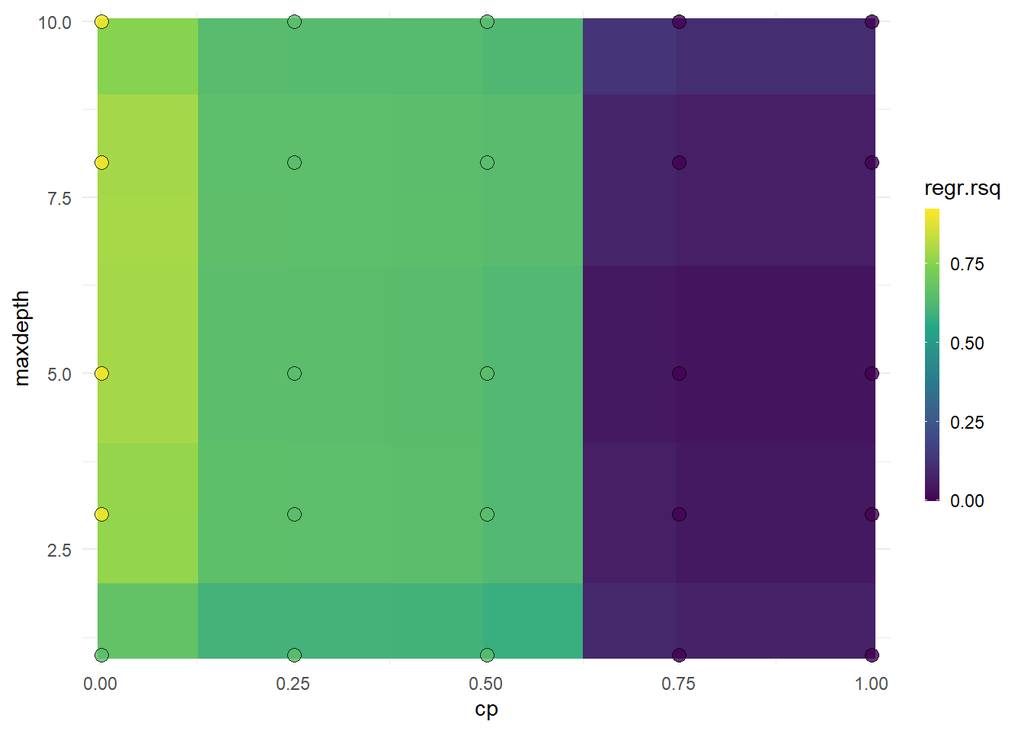

```r
mlr3viz::autoplot(instance, type = "surface")
```

# mlr3: Deploy Optimal Model

```r
learner$param_set$values = instance$result_learner_param_vals
learner$train(task)
learner$model
```

```
## n= 29839
##
## node), split, n, deviance, yval
##       * denotes terminal node
##
##  1) root 29839 413801.4000 12.030500
##    2) numeric_grade< 2.5 16587  71325.4300  9.346206
##      4) numeric_grade< 1.5 7574   8175.1040  7.346190 *
##      5) numeric_grade>=1.5 9013   7394.4150 11.026900 *
##    3) numeric_grade>=2.5 13252  73365.4500 15.390320
##      6) numeric_grade< 4.5 10076  22455.3500 14.414860
##       12) numeric_grade< 3.5 6059   5349.8220 13.542500 *
##       13) numeric_grade>=3.5 4017   5539.5290 15.730680
##         26) term< 48 2426   3051.3250 15.363940 *
##         27) term>=48 1591   1664.3350 16.289910 *
##      7) numeric_grade>=4.5 3176  10905.7500 18.485010
##       14) numeric_grade< 5.5 2149   4379.1350 17.718950
##         28) term< 48 647   1192.9980 16.986630 *
##         29) term>=48 1502   2689.6930 18.034400 *
##       15) numeric_grade>=5.5 1027   2626.5390 20.087990
##         30) numeric_grade< 6.5 803   1809.6590 19.744060 *
##         31) numeric_grade>=6.5 224    381.3789 21.320940 *
```

# mlr3: Predict

**R2 based on testdata: `loans_test`**

```r
measure <- msr("regr.rsq")
prediction <- learner$predict_newdata(loans_test)
prediction$score(measure)
```

```
##  regr.rsq
## 0.9271745
```

# Tidymodels: Explore the results

The function `collect_metrics()` gives us a tidy tibble with all the results: a row for each `.metric` and model

```r
tree_res %>%
  collect_metrics()
```

```
## # A tibble: 60 × 8
##    cost_complexity tree_depth .metric .estimator  mean     n std_err .config
##              <dbl>      <int> <chr>   <chr>      <dbl> <int>   <dbl> <chr>
##  1    0.0000000001          1 rmse    standard   2.20      3 0.00672 Preprocess…
##  2    0.0000000001          1 rsq     standard   0.651     3 0.00238 Preprocess…
##  3    0.0000000178          1 rmse    standard   2.20      3 0.00672 Preprocess…
##  4    0.0000000178          1 rsq     standard   0.651     3 0.00238 Preprocess…
##  5    0.00000316            1 rmse    standard   2.20      3 0.00672 Preprocess…
##  6    0.00000316            1 rsq     standard   0.651     3 0.00238 Preprocess…
##  7    0.000562              1 rmse    standard   2.20      3 0.00672 Preprocess…
##  8    0.000562              1 rsq     standard   0.651     3 0.00238 Preprocess…
##  9    0.1                   1 rmse    standard   2.20      3 0.00672 Preprocess…
## 10    0.1                   1 rsq     standard   0.651     3 0.00238 Preprocess…
## # … with 50 more rows
```

**Plot:**

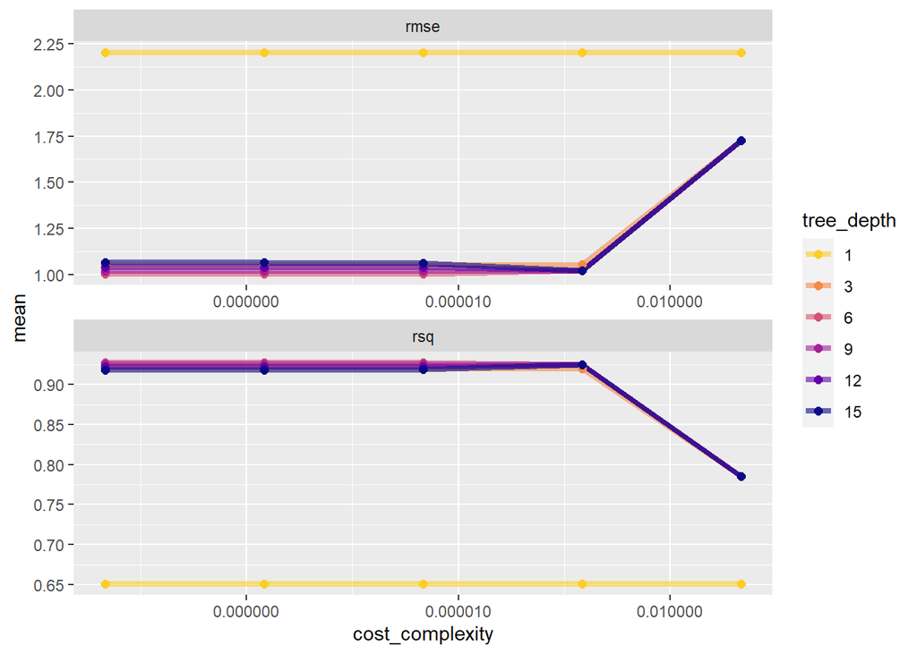

```r
tree_res %>%
  collect_metrics() %>%
  mutate(tree_depth = factor(tree_depth)) %>%
  ggplot(aes(cost_complexity, mean, color = tree_depth)) +
  geom_line(linewidth = 1.5, alpha = 0.6) +
  geom_point(size = 2) +
  facet_wrap(~ .metric, scales = "free", nrow = 2) +
  scale_x_log10(labels = scales::label_number()) +
  scale_color_viridis_d(option = "plasma", begin = .9, end = 0)
```

**Top 5 Candidate Models:**

```r
tree_res %>%
  show_best("rsq") # R2 ~ 0.92
```

```
## # A tibble: 5 × 8
##   cost_complexity tree_depth .metric .estimator  mean     n  std_err .config
##             <dbl>      <int> <chr>   <chr>      <dbl> <int>    <dbl> <chr>
## 1    0.0000000001          6 rsq     standard   0.928     3 0.00104  Preprocess…
## 2    0.0000000178          6 rsq     standard   0.928     3 0.00104  Preprocess…
## 3    0.00000316            6 rsq     standard   0.928     3 0.00104  Preprocess…
## 4    0.00000316            9 rsq     standard   0.926     3 0.000974 Preprocess…
## 5    0.0000000001          9 rsq     standard   0.926     3 0.000986 Preprocess…
```

**Best Model:**

```r
best_tree <- tree_res %>%
  select_best("rsq")

best_tree
```

```
## # A tibble: 1 × 3
##   cost_complexity tree_depth .config
##             <dbl>      <int> <chr>
## 1    0.0000000001          6 Preprocessor1_Model11
```

# Tidymodels: Finalizing the Model

Update (or “finalize”) our workflow object `tree_wf` with the values from `select_best()`

```r
final_wf <-
  tree_wf %>%
  finalize_workflow(best_tree)

final_wf
```

```
## ══ Workflow ════════════════════════════════════════════════════════════════════
## Preprocessor: Formula
## Model: decision_tree()
##
## ── Preprocessor ────────────────────────────────────────────────────────────────
## int_rate ~ .
##
## ── Model ───────────────────────────────────────────────────────────────────────
## Decision Tree Model Specification (regression)
##
## Main Arguments:
##   cost_complexity = 1e-10
##   tree_depth = 6
##
## Computational engine: rpart
```

# Tidymodels: Final Model with Test Data

Final model is calculated based on test-data to prevent any overfitting

**Please note:** The `final-final` model should be calculated on the whole data.frame.

# Sequential Tuning

**Classical tuning approaches**  
- A full grid search is not an effective approach to find best models - A random forest can reduce search time, but is stupid in a sense that it does not learn from prior run models

**Strategy: Sequential tuning**

Ref.: https://www.tidymodels.org/learn/work/bayes-opt/

- **Exploration** means that the search will consider candidates in untested space.
- **Exploitation** focuses in areas where the previous best results occurred.

Applying a *sequential tuning*, prior information gained from models will be used to determine next models to tune

**Set of parameters** has to be specified to control for during the tuning process:

```r
rpart_set <- extract_parameter_set_dials(tree_wf) # we set two hyperparameters to tune here:
rpart_set
```

```
## Collection of 2 parameters for tuning
##
##       identifier            type    object
##  cost_complexity cost_complexity nparam[+]
##       tree_depth      tree_depth nparam[+]
```

Start the sequential tuning with five initial models - please be aware that this is time consuming.

```r
SearchResult <-
  tree_wf %>%
  tune_bayes(
    resamples = cell_folds,
    # parameter to control for
    param_info = rpart_set,
    # Generate five at semi-random to start
    initial = 5,
    iter = 50,
    # How to measure performance
    metrics = metric_set(rsq),
    #grid = tree_grid,
    control = control_bayes(no_improve = 30,verbose = TRUE)
  )
```

```
## ❯  Generating a set of 5 initial parameter results
```

```
## ✓ Initialization complete
```

```
## ── Iteration 1 ─────────────────────────────────────────────────────────────────
```

```
## i Current best:      rsq=0.9276 (@iter 0)
```

```
## i Gaussian process model
```

```
## ✓ Gaussian process model
```

```
## i Generating 5000 candidates
```

```
## i Predicted candidates
```

```
## i cost_complexity=3.96e-06, tree_depth=15
```

```
## i Estimating performance
```

```
## i Fold1: preprocessor 1/1
```

```
## ✓ Fold1: preprocessor 1/1
```

```
## i Fold1: preprocessor 1/1, model 1/1
```

```
## ✓ Fold1: preprocessor 1/1, model 1/1
```

```
## i Fold1: preprocessor 1/1, model 1/1 (predictions)
```

```
## i Fold2: preprocessor 1/1
```

```
## ✓ Fold2: preprocessor 1/1
```

```
## i Fold2: preprocessor 1/1, model 1/1
```

```
## ✓ Fold2: preprocessor 1/1, model 1/1
```

```
## i Fold2: preprocessor 1/1, model 1/1 (predictions)
```

```
## i Fold3: preprocessor 1/1
```

```
## ✓ Fold3: preprocessor 1/1
```

```
## i Fold3: preprocessor 1/1, model 1/1
```

```
## ✓ Fold3: preprocessor 1/1, model 1/1
```

```
## i Fold3: preprocessor 1/1, model 1/1 (predictions)
```

```
## ✓ Estimating performance
```

```
## ⓧ Newest results:    rsq=0.9189 (+/-0.00077)
```

```
## ── Iteration 2 ─────────────────────────────────────────────────────────────────
```

```
## i Current best:      rsq=0.9276 (@iter 0)
```

```
## i Gaussian process model
```

```
## ✓ Gaussian process model
```

```
## i Generating 5000 candidates
```

```
## i Predicted candidates
```

```
## i cost_complexity=5.65e-05, tree_depth=1
```

```
## i Estimating performance
```

```
## i Fold1: preprocessor 1/1
```

```
## ✓ Fold1: preprocessor 1/1
```

```
## i Fold1: preprocessor 1/1, model 1/1
```

```
## ✓ Fold1: preprocessor 1/1, model 1/1
```

```
## i Fold1: preprocessor 1/1, model 1/1 (predictions)
```

```
## i Fold2: preprocessor 1/1
```

```
## ✓ Fold2: preprocessor 1/1
```

```
## i Fold2: preprocessor 1/1, model 1/1
```

```
## ✓ Fold2: preprocessor 1/1, model 1/1
```

```
## i Fold2: preprocessor 1/1, model 1/1 (predictions)
```

```
## i Fold3: preprocessor 1/1
```

```
## ✓ Fold3: preprocessor 1/1
```

```
## i Fold3: preprocessor 1/1, model 1/1
```

```
## ✓ Fold3: preprocessor 1/1, model 1/1
```

```
## i Fold3: preprocessor 1/1, model 1/1 (predictions)
```

```
## ✓ Estimating performance
```

```
## ⓧ Newest results:    rsq=0.6507 (+/-0.00238)
```

```
## ── Iteration 3 ─────────────────────────────────────────────────────────────────
```

```
## i Current best:      rsq=0.9276 (@iter 0)
```

```
## i Gaussian process model
```

```
## ✓ Gaussian process model
```

```
## i Generating 5000 candidates
```

```
## i Predicted candidates
```

```
## i cost_complexity=0.0957, tree_depth=7
```

```
## i Estimating performance
```

```
## i Fold1: preprocessor 1/1
```

```
## ✓ Fold1: preprocessor 1/1
```

```
## i Fold1: preprocessor 1/1, model 1/1
```

```
## ✓ Fold1: preprocessor 1/1, model 1/1
```

```
## i Fold1: preprocessor 1/1, model 1/1 (predictions)
```

```
## i Fold2: preprocessor 1/1
```

```
## ✓ Fold2: preprocessor 1/1
```

```
## i Fold2: preprocessor 1/1, model 1/1
```

```
## ✓ Fold2: preprocessor 1/1, model 1/1
```

```
## i Fold2: preprocessor 1/1, model 1/1 (predictions)
```

```
## i Fold3: preprocessor 1/1
```

```
## ✓ Fold3: preprocessor 1/1
```

```
## i Fold3: preprocessor 1/1, model 1/1
```

```
## ✓ Fold3: preprocessor 1/1, model 1/1
```

```
## i Fold3: preprocessor 1/1, model 1/1 (predictions)
```

```
## ✓ Estimating performance
```

```
## ⓧ Newest results:    rsq=0.8828 (+/-0.000768)
```

```
## ── Iteration 4 ─────────────────────────────────────────────────────────────────
```

```
## i Current best:      rsq=0.9276 (@iter 0)
```

```
## i Gaussian process model
```

```
## ✓ Gaussian process model
```

```
## i Generating 5000 candidates
```

```
## i Predicted candidates
```

```
## i cost_complexity=1.14e-10, tree_depth=5
```

```
## i Estimating performance
```

```
## i Fold1: preprocessor 1/1
```

```
## ✓ Fold1: preprocessor 1/1
```

```
## i Fold1: preprocessor 1/1, model 1/1
```

```
## ✓ Fold1: preprocessor 1/1, model 1/1
```

```
## i Fold1: preprocessor 1/1, model 1/1 (predictions)
```

```
## i Fold2: preprocessor 1/1
```

```
## ✓ Fold2: preprocessor 1/1
```

```
## i Fold2: preprocessor 1/1, model 1/1
```

```
## ✓ Fold2: preprocessor 1/1, model 1/1
```

```
## i Fold2: preprocessor 1/1, model 1/1 (predictions)
```

```
## i Fold3: preprocessor 1/1
```

```
## ✓ Fold3: preprocessor 1/1
```

```
## i Fold3: preprocessor 1/1, model 1/1
```

```
## ✓ Fold3: preprocessor 1/1, model 1/1
```

```
## i Fold3: preprocessor 1/1, model 1/1 (predictions)
```

```
## ✓ Estimating performance
```

```
## ⓧ Newest results:    rsq=0.9271 (+/-0.00094)
```

```
## ── Iteration 5 ─────────────────────────────────────────────────────────────────
```

```
## i Current best:      rsq=0.9276 (@iter 0)
```

```
## i Gaussian process model
```

```
## ✓ Gaussian process model
```

```
## i Generating 5000 candidates
```

```
## i Predicted candidates
```

```
## i cost_complexity=0.0973, tree_depth=5
```

```
## i Estimating performance
```

```
## i Fold1: preprocessor 1/1
```

```
## ✓ Fold1: preprocessor 1/1
```

```
## i Fold1: preprocessor 1/1, model 1/1
```

```
## ✓ Fold1: preprocessor 1/1, model 1/1
```

```
## i Fold1: preprocessor 1/1, model 1/1 (predictions)
```

```
## i Fold2: preprocessor 1/1
```

```
## ✓ Fold2: preprocessor 1/1
```

```
## i Fold2: preprocessor 1/1, model 1/1
```

```
## ✓ Fold2: preprocessor 1/1, model 1/1
```

```
## i Fold2: preprocessor 1/1, model 1/1 (predictions)
```

```
## i Fold3: preprocessor 1/1
```

```
## ✓ Fold3: preprocessor 1/1
```

```
## i Fold3: preprocessor 1/1, model 1/1
```

```
## ✓ Fold3: preprocessor 1/1, model 1/1
```

```
## i Fold3: preprocessor 1/1, model 1/1 (predictions)
```

```
## ✓ Estimating performance
```

```
## ⓧ Newest results:    rsq=0.8166 (+/-0.0333)
```

```
## ── Iteration 6 ─────────────────────────────────────────────────────────────────
```

```
## i Current best:      rsq=0.9276 (@iter 0)
```

```
## i Gaussian process model
```

```
## ✓ Gaussian process model
```

```
## i Generating 5000 candidates
```

```
## i Predicted candidates
```

```
## i cost_complexity=2.1e-09, tree_depth=6
```

```
## i Estimating performance
```

```
## i Fold1: preprocessor 1/1
```

```
## ✓ Fold1: preprocessor 1/1
```

```
## i Fold1: preprocessor 1/1, model 1/1
```

```
## ✓ Fold1: preprocessor 1/1, model 1/1
```

```
## i Fold1: preprocessor 1/1, model 1/1 (predictions)
```

```
## i Fold2: preprocessor 1/1
```

```
## ✓ Fold2: preprocessor 1/1
```

```
## i Fold2: preprocessor 1/1, model 1/1
```

```
## ✓ Fold2: preprocessor 1/1, model 1/1
```

```
## i Fold2: preprocessor 1/1, model 1/1 (predictions)
```

```
## i Fold3: preprocessor 1/1
```

```
## ✓ Fold3: preprocessor 1/1
```

```
## i Fold3: preprocessor 1/1, model 1/1
```

```
## ✓ Fold3: preprocessor 1/1, model 1/1
```

```
## i Fold3: preprocessor 1/1, model 1/1 (predictions)
```

```
## ✓ Estimating performance
```

```
## ♥ Newest results:    rsq=0.9277 (+/-0.00104)
```

```
## ── Iteration 7 ─────────────────────────────────────────────────────────────────
```

```
## i Current best:      rsq=0.9277 (@iter 6)
```

```
## i Gaussian process model
```

```
## ✓ Gaussian process model
```

```
## i Generating 5000 candidates
```

```
## i Predicted candidates
```

```
## i cost_complexity=0.0334, tree_depth=14
```

```
## i Estimating performance
```

```
## i Fold1: preprocessor 1/1
```

```
## ✓ Fold1: preprocessor 1/1
```

```
## i Fold1: preprocessor 1/1, model 1/1
```

```
## ✓ Fold1: preprocessor 1/1, model 1/1
```

```
## i Fold1: preprocessor 1/1, model 1/1 (predictions)
```

```
## i Fold2: preprocessor 1/1
```

```
## ✓ Fold2: preprocessor 1/1
```

```
## i Fold2: preprocessor 1/1, model 1/1
```

```
## ✓ Fold2: preprocessor 1/1, model 1/1
```

```
## i Fold2: preprocessor 1/1, model 1/1 (predictions)
```

```
## i Fold3: preprocessor 1/1
```

```
## ✓ Fold3: preprocessor 1/1
```

```
## i Fold3: preprocessor 1/1, model 1/1
```

```
## ✓ Fold3: preprocessor 1/1, model 1/1
```

```
## i Fold3: preprocessor 1/1, model 1/1 (predictions)
```

```
## ✓ Estimating performance
```

```
## ⓧ Newest results:    rsq=0.8828 (+/-0.000768)
```

```
## ── Iteration 8 ─────────────────────────────────────────────────────────────────
```

```
## i Current best:      rsq=0.9277 (@iter 6)
```

```
## i Gaussian process model
```

```
## ✓ Gaussian process model
```

```
## i Generating 5000 candidates
```

```
## i Predicted candidates
```

```
## i cost_complexity=1.04e-07, tree_depth=12
```

```
## i Estimating performance
```

```
## i Fold1: preprocessor 1/1
```

```
## ✓ Fold1: preprocessor 1/1
```

```
## i Fold1: preprocessor 1/1, model 1/1
```

```
## ✓ Fold1: preprocessor 1/1, model 1/1
```

```
## i Fold1: preprocessor 1/1, model 1/1 (predictions)
```

```
## i Fold2: preprocessor 1/1
```

```
## ✓ Fold2: preprocessor 1/1
```

```
## i Fold2: preprocessor 1/1, model 1/1
```

```
## ✓ Fold2: preprocessor 1/1, model 1/1
```

```
## i Fold2: preprocessor 1/1, model 1/1 (predictions)
```

```
## i Fold3: preprocessor 1/1
```

```
## ✓ Fold3: preprocessor 1/1
```

```
## i Fold3: preprocessor 1/1, model 1/1
```

```
## ✓ Fold3: preprocessor 1/1, model 1/1
```

```
## i Fold3: preprocessor 1/1, model 1/1 (predictions)
```

```
## ✓ Estimating performance
```

```
## ⓧ Newest results:    rsq=0.922 (+/-0.000969)
```

```
## ── Iteration 9 ─────────────────────────────────────────────────────────────────
```

```
## i Current best:      rsq=0.9277 (@iter 6)
```

```
## i Gaussian process model
```

```
## ✓ Gaussian process model
```

```
## i Generating 5000 candidates
```

```
## i Predicted candidates
```

```
## i cost_complexity=1.53e-09, tree_depth=14
```

```
## i Estimating performance
```

```
## i Fold1: preprocessor 1/1
```

```
## ✓ Fold1: preprocessor 1/1
```

```
## i Fold1: preprocessor 1/1, model 1/1
```

```
## ✓ Fold1: preprocessor 1/1, model 1/1
```

```
## i Fold1: preprocessor 1/1, model 1/1 (predictions)
```

```
## i Fold2: preprocessor 1/1
```

```
## ✓ Fold2: preprocessor 1/1
```

```
## i Fold2: preprocessor 1/1, model 1/1
```

```
## ✓ Fold2: preprocessor 1/1, model 1/1
```

```
## i Fold2: preprocessor 1/1, model 1/1 (predictions)
```

```
## i Fold3: preprocessor 1/1
```

```
## ✓ Fold3: preprocessor 1/1
```

```
## i Fold3: preprocessor 1/1, model 1/1
```

```
## ✓ Fold3: preprocessor 1/1, model 1/1
```

```
## i Fold3: preprocessor 1/1, model 1/1 (predictions)
```

```
## ✓ Estimating performance
```

```
## ⓧ Newest results:    rsq=0.9194 (+/-0.000907)
```

```
## ── Iteration 10 ────────────────────────────────────────────────────────────────
```

```
## i Current best:      rsq=0.9277 (@iter 6)
```

```
## i Gaussian process model
```

```
## ✓ Gaussian process model
```

```
## i Generating 5000 candidates
```

```
## i Predicted candidates
```

```
## i cost_complexity=0.000166, tree_depth=10
```

```
## i Estimating performance
```

```
## i Fold1: preprocessor 1/1
```

```
## ✓ Fold1: preprocessor 1/1
```

```
## i Fold1: preprocessor 1/1, model 1/1
```

```
## ✓ Fold1: preprocessor 1/1, model 1/1
```

```
## i Fold1: preprocessor 1/1, model 1/1 (predictions)
```

```
## i Fold2: preprocessor 1/1
```

```
## ✓ Fold2: preprocessor 1/1
```

```
## i Fold2: preprocessor 1/1, model 1/1
```

```
## ✓ Fold2: preprocessor 1/1, model 1/1
```

```
## i Fold2: preprocessor 1/1, model 1/1 (predictions)
```

```
## i Fold3: preprocessor 1/1
```

```
## ✓ Fold3: preprocessor 1/1
```

```
## i Fold3: preprocessor 1/1, model 1/1
```

```
## ✓ Fold3: preprocessor 1/1, model 1/1
```

```
## i Fold3: preprocessor 1/1, model 1/1 (predictions)
```

```
## ✓ Estimating performance
```

```
## ⓧ Newest results:    rsq=0.9265 (+/-0.000679)
```

```
## ── Iteration 11 ────────────────────────────────────────────────────────────────
```

```
## i Current best:      rsq=0.9277 (@iter 6)
```

```
## i Gaussian process model
```

```
## ✓ Gaussian process model
```

```
## i Generating 5000 candidates
```

```
## i Predicted candidates
```

```
## i cost_complexity=1.03e-10, tree_depth=13
```

```
## i Estimating performance
```

```
## i Fold1: preprocessor 1/1
```

```
## ✓ Fold1: preprocessor 1/1
```

```
## i Fold1: preprocessor 1/1, model 1/1
```

```
## ✓ Fold1: preprocessor 1/1, model 1/1
```

```
## i Fold1: preprocessor 1/1, model 1/1 (predictions)
```

```
## i Fold2: preprocessor 1/1
```

```
## ✓ Fold2: preprocessor 1/1
```

```
## i Fold2: preprocessor 1/1, model 1/1
```

```
## ✓ Fold2: preprocessor 1/1, model 1/1
```

```
## i Fold2: preprocessor 1/1, model 1/1 (predictions)
```

```
## i Fold3: preprocessor 1/1
```

```
## ✓ Fold3: preprocessor 1/1
```

```
## i Fold3: preprocessor 1/1, model 1/1
```

```
## ✓ Fold3: preprocessor 1/1, model 1/1
```

```
## i Fold3: preprocessor 1/1, model 1/1 (predictions)
```

```
## ✓ Estimating performance
```

```
## ⓧ Newest results:    rsq=0.9206 (+/-0.00087)
```

```
## ── Iteration 12 ────────────────────────────────────────────────────────────────
```

```
## i Current best:      rsq=0.9277 (@iter 6)
```

```
## i Gaussian process model
```

```
## ✓ Gaussian process model
```

```
## i Generating 5000 candidates
```

```
## i Predicted candidates
```

```
## i cost_complexity=0.091, tree_depth=12
```

```
## i Estimating performance
```

```
## i Fold1: preprocessor 1/1
```

```
## ✓ Fold1: preprocessor 1/1
```

```
## i Fold1: preprocessor 1/1, model 1/1
```

```
## ✓ Fold1: preprocessor 1/1, model 1/1
```

```
## i Fold1: preprocessor 1/1, model 1/1 (predictions)
```

```
## i Fold2: preprocessor 1/1
```

```
## ✓ Fold2: preprocessor 1/1
```

```
## i Fold2: preprocessor 1/1, model 1/1
```

```
## ✓ Fold2: preprocessor 1/1, model 1/1
```

```
## i Fold2: preprocessor 1/1, model 1/1 (predictions)
```

```
## i Fold3: preprocessor 1/1
```

```
## ✓ Fold3: preprocessor 1/1
```

```
## i Fold3: preprocessor 1/1, model 1/1
```

```
## ✓ Fold3: preprocessor 1/1, model 1/1
```

```
## i Fold3: preprocessor 1/1, model 1/1 (predictions)
```

```
## ✓ Estimating performance
```

```
## ⓧ Newest results:    rsq=0.8828 (+/-0.000768)
```

```
## ── Iteration 13 ────────────────────────────────────────────────────────────────
```

```
## i Current best:      rsq=0.9277 (@iter 6)
```

```
## i Gaussian process model
```

```
## ✓ Gaussian process model
```

```
## i Generating 5000 candidates
```

```
## i Predicted candidates
```

```
## i cost_complexity=2.96e-07, tree_depth=13
```

```
## i Estimating performance
```

```
## i Fold1: preprocessor 1/1
```

```
## ✓ Fold1: preprocessor 1/1
```

```
## i Fold1: preprocessor 1/1, model 1/1
```

```
## ✓ Fold1: preprocessor 1/1, model 1/1
```

```
## i Fold1: preprocessor 1/1, model 1/1 (predictions)
```

```
## i Fold2: preprocessor 1/1
```

```
## ✓ Fold2: preprocessor 1/1
```

```
## i Fold2: preprocessor 1/1, model 1/1
```

```
## ✓ Fold2: preprocessor 1/1, model 1/1
```

```
## i Fold2: preprocessor 1/1, model 1/1 (predictions)
```

```
## i Fold3: preprocessor 1/1
```

```
## ✓ Fold3: preprocessor 1/1
```

```
## i Fold3: preprocessor 1/1, model 1/1
```

```
## ✓ Fold3: preprocessor 1/1, model 1/1
```

```
## i Fold3: preprocessor 1/1, model 1/1 (predictions)
```

```
## ✓ Estimating performance
```

```
## ⓧ Newest results:    rsq=0.9206 (+/-0.00087)
```

```
## ── Iteration 14 ────────────────────────────────────────────────────────────────
```

```
## i Current best:      rsq=0.9277 (@iter 6)
```

```
## i Gaussian process model
```

```
## ✓ Gaussian process model
```

```
## i Generating 5000 candidates
```

```
## i Predicted candidates
```

```
## i cost_complexity=4.18e-10, tree_depth=8
```

```
## i Estimating performance
```

```
## i Fold1: preprocessor 1/1
```

```
## ✓ Fold1: preprocessor 1/1
```

```
## i Fold1: preprocessor 1/1, model 1/1
```

```
## ✓ Fold1: preprocessor 1/1, model 1/1
```

```
## i Fold1: preprocessor 1/1, model 1/1 (predictions)
```

```
## i Fold2: preprocessor 1/1
```

```
## ✓ Fold2: preprocessor 1/1
```

```
## i Fold2: preprocessor 1/1, model 1/1
```

```
## ✓ Fold2: preprocessor 1/1, model 1/1
```

```
## i Fold2: preprocessor 1/1, model 1/1 (predictions)
```

```
## i Fold3: preprocessor 1/1
```

```
## ✓ Fold3: preprocessor 1/1
```

```
## i Fold3: preprocessor 1/1, model 1/1
```

```
## ✓ Fold3: preprocessor 1/1, model 1/1
```

```
## i Fold3: preprocessor 1/1, model 1/1 (predictions)
```

```
## ✓ Estimating performance
```

```
## ⓧ Newest results:    rsq=0.9266 (+/-0.00105)
```

```
## ── Iteration 15 ────────────────────────────────────────────────────────────────
```

```
## i Current best:      rsq=0.9277 (@iter 6)
```

```
## i Gaussian process model
```

```
## ✓ Gaussian process model
```

```
## i Generating 5000 candidates
```

```
## i Predicted candidates
```

```
## i cost_complexity=1.79e-06, tree_depth=7
```

```
## i Estimating performance
```

```
## i Fold1: preprocessor 1/1
```

```
## ✓ Fold1: preprocessor 1/1
```

```
## i Fold1: preprocessor 1/1, model 1/1
```

```
## ✓ Fold1: preprocessor 1/1, model 1/1
```

```
## i Fold1: preprocessor 1/1, model 1/1 (predictions)
```

```
## i Fold2: preprocessor 1/1
```

```
## ✓ Fold2: preprocessor 1/1
```

```
## i Fold2: preprocessor 1/1, model 1/1
```

```
## ✓ Fold2: preprocessor 1/1, model 1/1
```

```
## i Fold2: preprocessor 1/1, model 1/1 (predictions)
```

```
## i Fold3: preprocessor 1/1
```

```
## ✓ Fold3: preprocessor 1/1
```

```
## i Fold3: preprocessor 1/1, model 1/1
```

```
## ✓ Fold3: preprocessor 1/1, model 1/1
```

```
## i Fold3: preprocessor 1/1, model 1/1 (predictions)
```

```
## ✓ Estimating performance
```

```
## ⓧ Newest results:    rsq=0.9273 (+/-0.00102)
```

```
## ── Iteration 16 ────────────────────────────────────────────────────────────────
```

```
## i Current best:      rsq=0.9277 (@iter 6)
```

```
## i Gaussian process model
```

```
## ✓ Gaussian process model
```

```
## i Generating 5000 candidates
```

```
## i Predicted candidates
```

```
## i cost_complexity=6.54e-08, tree_depth=5
```

```
## i Estimating performance
```

```
## i Fold1: preprocessor 1/1
```

```
## ✓ Fold1: preprocessor 1/1
```

```
## i Fold1: preprocessor 1/1, model 1/1
```

```
## ✓ Fold1: preprocessor 1/1, model 1/1
```

```
## i Fold1: preprocessor 1/1, model 1/1 (predictions)
```

```
## i Fold2: preprocessor 1/1
```

```
## ✓ Fold2: preprocessor 1/1
```

```
## i Fold2: preprocessor 1/1, model 1/1
```

```
## ✓ Fold2: preprocessor 1/1, model 1/1
```

```
## i Fold2: preprocessor 1/1, model 1/1 (predictions)
```

```
## i Fold3: preprocessor 1/1
```

```
## ✓ Fold3: preprocessor 1/1
```

```
## i Fold3: preprocessor 1/1, model 1/1
```

```
## ✓ Fold3: preprocessor 1/1, model 1/1
```

```
## i Fold3: preprocessor 1/1, model 1/1 (predictions)
```

```
## ✓ Estimating performance
```

```
## ⓧ Newest results:    rsq=0.9271 (+/-0.00094)
```

```
## ── Iteration 17 ────────────────────────────────────────────────────────────────
```

```
## i Current best:      rsq=0.9277 (@iter 6)
```

```
## i Gaussian process model
```

```
## ✓ Gaussian process model
```

```
## i Generating 5000 candidates
```

```
## i Predicted candidates
```

```
## i cost_complexity=1.04e-10, tree_depth=15
```

```
## i Estimating performance
```

```
## i Fold1: preprocessor 1/1
```

```
## ✓ Fold1: preprocessor 1/1
```

```
## i Fold1: preprocessor 1/1, model 1/1
```

```
## ✓ Fold1: preprocessor 1/1, model 1/1
```

```
## i Fold1: preprocessor 1/1, model 1/1 (predictions)
```

```
## i Fold2: preprocessor 1/1
```

```
## ✓ Fold2: preprocessor 1/1
```

```
## i Fold2: preprocessor 1/1, model 1/1
```

```
## ✓ Fold2: preprocessor 1/1, model 1/1
```

```
## i Fold2: preprocessor 1/1, model 1/1 (predictions)
```

```
## i Fold3: preprocessor 1/1
```

```
## ✓ Fold3: preprocessor 1/1
```

```
## i Fold3: preprocessor 1/1, model 1/1
```

```
## ✓ Fold3: preprocessor 1/1, model 1/1
```

```
## i Fold3: preprocessor 1/1, model 1/1 (predictions)
```

```
## ✓ Estimating performance
```

```
## ⓧ Newest results:    rsq=0.9183 (+/-0.000811)
```

```
## ── Iteration 18 ────────────────────────────────────────────────────────────────
```

```
## i Current best:      rsq=0.9277 (@iter 6)
```

```
## i Gaussian process model
```

```
## ✓ Gaussian process model
```

```
## i Generating 5000 candidates
```

```
## i Predicted candidates
```

```
## i cost_complexity=3.4e-10, tree_depth=4
```

```
## i Estimating performance
```

```
## i Fold1: preprocessor 1/1
```

```
## ✓ Fold1: preprocessor 1/1
```

```
## i Fold1: preprocessor 1/1, model 1/1
```

```
## ✓ Fold1: preprocessor 1/1, model 1/1
```

```
## i Fold1: preprocessor 1/1, model 1/1 (predictions)
```

```
## i Fold2: preprocessor 1/1
```

```
## ✓ Fold2: preprocessor 1/1
```

```
## i Fold2: preprocessor 1/1, model 1/1
```

```
## ✓ Fold2: preprocessor 1/1, model 1/1
```

```
## i Fold2: preprocessor 1/1, model 1/1 (predictions)
```

```
## i Fold3: preprocessor 1/1
```

```
## ✓ Fold3: preprocessor 1/1
```

```
## i Fold3: preprocessor 1/1, model 1/1
```

```
## ✓ Fold3: preprocessor 1/1, model 1/1
```

```
## i Fold3: preprocessor 1/1, model 1/1 (predictions)
```

```
## ✓ Estimating performance
```

```
## ⓧ Newest results:    rsq=0.9252 (+/-0.000923)
```

```
## ── Iteration 19 ────────────────────────────────────────────────────────────────
```

```
## i Current best:      rsq=0.9277 (@iter 6)
```

```
## i Gaussian process model
```

```
## ✓ Gaussian process model
```

```
## i Generating 5000 candidates
```

```
## i Predicted candidates
```

```
## i cost_complexity=2.25e-07, tree_depth=6
```

```
## i Estimating performance
```

```
## i Fold1: preprocessor 1/1
```

```
## ✓ Fold1: preprocessor 1/1
```

```
## i Fold1: preprocessor 1/1, model 1/1
```

```
## ✓ Fold1: preprocessor 1/1, model 1/1
```

```
## i Fold1: preprocessor 1/1, model 1/1 (predictions)
```

```
## i Fold2: preprocessor 1/1
```

```
## ✓ Fold2: preprocessor 1/1
```

```
## i Fold2: preprocessor 1/1, model 1/1
```

```
## ✓ Fold2: preprocessor 1/1, model 1/1
```

```
## i Fold2: preprocessor 1/1, model 1/1 (predictions)
```

```
## i Fold3: preprocessor 1/1
```

```
## ✓ Fold3: preprocessor 1/1
```

```
## i Fold3: preprocessor 1/1, model 1/1
```

```
## ✓ Fold3: preprocessor 1/1, model 1/1
```

```
## i Fold3: preprocessor 1/1, model 1/1 (predictions)
```

```
## ✓ Estimating performance
```

```
## ⓧ Newest results:    rsq=0.9277 (+/-0.00104)
```

```
## ── Iteration 20 ────────────────────────────────────────────────────────────────
```

```
## i Current best:      rsq=0.9277 (@iter 6)
```

```
## i Gaussian process model
```

```
## ✓ Gaussian process model
```

```
## i Generating 5000 candidates
```

```
## i Predicted candidates
```

```
## i cost_complexity=0.000138, tree_depth=8
```

```
## i Estimating performance
```

```
## i Fold1: preprocessor 1/1
```

```
## ✓ Fold1: preprocessor 1/1
```

```
## i Fold1: preprocessor 1/1, model 1/1
```

```
## ✓ Fold1: preprocessor 1/1, model 1/1
```

```
## i Fold1: preprocessor 1/1, model 1/1 (predictions)
```

```
## i Fold2: preprocessor 1/1
```

```
## ✓ Fold2: preprocessor 1/1
```

```
## i Fold2: preprocessor 1/1, model 1/1
```

```
## ✓ Fold2: preprocessor 1/1, model 1/1
```

```
## i Fold2: preprocessor 1/1, model 1/1 (predictions)
```

```
## i Fold3: preprocessor 1/1
```

```
## ✓ Fold3: preprocessor 1/1
```

```
## i Fold3: preprocessor 1/1, model 1/1
```

```
## ✓ Fold3: preprocessor 1/1, model 1/1
```

```
## i Fold3: preprocessor 1/1, model 1/1 (predictions)
```

```
## ✓ Estimating performance
```

```
## ⓧ Newest results:    rsq=0.9269 (+/-0.000766)
```

```
## ── Iteration 21 ────────────────────────────────────────────────────────────────
```

```
## i Current best:      rsq=0.9277 (@iter 6)
```

```
## i Gaussian process model
```

```
## ✓ Gaussian process model
```

```
## i Generating 5000 candidates
```

```
## i Predicted candidates
```

```
## i cost_complexity=9.17e-06, tree_depth=11
```

```
## i Estimating performance
```

```
## i Fold1: preprocessor 1/1
```

```
## ✓ Fold1: preprocessor 1/1
```

```
## i Fold1: preprocessor 1/1, model 1/1
```

```
## ✓ Fold1: preprocessor 1/1, model 1/1
```

```
## i Fold1: preprocessor 1/1, model 1/1 (predictions)
```

```
## i Fold2: preprocessor 1/1
```

```
## ✓ Fold2: preprocessor 1/1
```

```
## i Fold2: preprocessor 1/1, model 1/1
```

```
## ✓ Fold2: preprocessor 1/1, model 1/1
```

```
## i Fold2: preprocessor 1/1, model 1/1 (predictions)
```

```
## i Fold3: preprocessor 1/1
```

```
## ✓ Fold3: preprocessor 1/1
```

```
## i Fold3: preprocessor 1/1, model 1/1
```

```
## ✓ Fold3: preprocessor 1/1, model 1/1
```

```
## i Fold3: preprocessor 1/1, model 1/1 (predictions)
```

```
## ✓ Estimating performance
```

```
## ⓧ Newest results:    rsq=0.9244 (+/-0.00108)
```

```
## ── Iteration 22 ────────────────────────────────────────────────────────────────
```

```
## i Current best:      rsq=0.9277 (@iter 6)
```

```
## i Gaussian process model
```

```
## ✓ Gaussian process model
```

```
## i Generating 5000 candidates
```

```
## i Predicted candidates
```

```
## i cost_complexity=0.0997, tree_depth=9
```

```
## i Estimating performance
```

```
## i Fold1: preprocessor 1/1
```

```
## ✓ Fold1: preprocessor 1/1
```

```
## i Fold1: preprocessor 1/1, model 1/1
```

```
## ✓ Fold1: preprocessor 1/1, model 1/1
```

```
## i Fold1: preprocessor 1/1, model 1/1 (predictions)
```

```
## i Fold2: preprocessor 1/1
```

```
## ✓ Fold2: preprocessor 1/1
```

```
## i Fold2: preprocessor 1/1, model 1/1
```

```
## ✓ Fold2: preprocessor 1/1, model 1/1
```

```
## i Fold2: preprocessor 1/1, model 1/1 (predictions)
```

```
## i Fold3: preprocessor 1/1
```

```
## ✓ Fold3: preprocessor 1/1
```

```
## i Fold3: preprocessor 1/1, model 1/1
```

```
## ✓ Fold3: preprocessor 1/1, model 1/1
```

```
## i Fold3: preprocessor 1/1, model 1/1 (predictions)
```

```
## ✓ Estimating performance
```

```
## ⓧ Newest results:    rsq=0.7855 (+/-0.00229)
```

```
## ── Iteration 23 ────────────────────────────────────────────────────────────────
```

```
## i Current best:      rsq=0.9277 (@iter 6)
```

```
## i Gaussian process model
```

```
## ✓ Gaussian process model
```

```
## i Generating 5000 candidates
```

```
## i Predicted candidates
```

```
## i cost_complexity=3.17e-06, tree_depth=10
```

```
## i Estimating performance
```

```
## i Fold1: preprocessor 1/1
```

```
## ✓ Fold1: preprocessor 1/1
```

```
## i Fold1: preprocessor 1/1, model 1/1
```

```
## ✓ Fold1: preprocessor 1/1, model 1/1
```

```
## i Fold1: preprocessor 1/1, model 1/1 (predictions)
```

```
## i Fold2: preprocessor 1/1
```

```
## ✓ Fold2: preprocessor 1/1
```

```
## i Fold2: preprocessor 1/1, model 1/1
```

```
## ✓ Fold2: preprocessor 1/1, model 1/1
```

```
## i Fold2: preprocessor 1/1, model 1/1 (predictions)
```

```
## i Fold3: preprocessor 1/1
```

```
## ✓ Fold3: preprocessor 1/1
```

```
## i Fold3: preprocessor 1/1, model 1/1
```

```
## ✓ Fold3: preprocessor 1/1, model 1/1
```

```
## i Fold3: preprocessor 1/1, model 1/1 (predictions)
```

```
## ✓ Estimating performance
```

```
## ⓧ Newest results:    rsq=0.9244 (+/-0.000945)
```

```
## ── Iteration 24 ────────────────────────────────────────────────────────────────
```

```
## i Current best:      rsq=0.9277 (@iter 6)
```

```
## i Gaussian process model
```

```
## ✓ Gaussian process model
```

```
## i Generating 5000 candidates
```

```
## i Predicted candidates
```

```
## i cost_complexity=9.13e-05, tree_depth=7
```

```
## i Estimating performance
```

```
## i Fold1: preprocessor 1/1
```

```
## ✓ Fold1: preprocessor 1/1
```

```
## i Fold1: preprocessor 1/1, model 1/1
```

```
## ✓ Fold1: preprocessor 1/1, model 1/1
```

```
## i Fold1: preprocessor 1/1, model 1/1 (predictions)
```

```
## i Fold2: preprocessor 1/1
```

```
## ✓ Fold2: preprocessor 1/1
```

```
## i Fold2: preprocessor 1/1, model 1/1
```

```
## ✓ Fold2: preprocessor 1/1, model 1/1
```

```
## i Fold2: preprocessor 1/1, model 1/1 (predictions)
```

```
## i Fold3: preprocessor 1/1
```

```
## ✓ Fold3: preprocessor 1/1
```

```
## i Fold3: preprocessor 1/1, model 1/1
```

```
## ✓ Fold3: preprocessor 1/1, model 1/1
```

```
## i Fold3: preprocessor 1/1, model 1/1 (predictions)
```

```
## ✓ Estimating performance
```

```
## ⓧ Newest results:    rsq=0.9271 (+/-0.000866)
```

```
## ── Iteration 25 ────────────────────────────────────────────────────────────────
```

```
## i Current best:      rsq=0.9277 (@iter 6)
```

```
## i Gaussian process model
```

```
## ✓ Gaussian process model
```

```
## i Generating 5000 candidates
```

```
## i Predicted candidates
```

```
## i cost_complexity=0.000131, tree_depth=12
```

```
## i Estimating performance
```

```
## i Fold1: preprocessor 1/1
```

```
## ✓ Fold1: preprocessor 1/1
```

```
## i Fold1: preprocessor 1/1, model 1/1
```

```
## ✓ Fold1: preprocessor 1/1, model 1/1
```

```
## i Fold1: preprocessor 1/1, model 1/1 (predictions)
```

```
## i Fold2: preprocessor 1/1
```

```
## ✓ Fold2: preprocessor 1/1
```

```
## i Fold2: preprocessor 1/1, model 1/1
```

```
## ✓ Fold2: preprocessor 1/1, model 1/1
```

```
## i Fold2: preprocessor 1/1, model 1/1 (predictions)
```

```
## i Fold3: preprocessor 1/1
```

```
## ✓ Fold3: preprocessor 1/1
```

```
## i Fold3: preprocessor 1/1, model 1/1
```

```
## ✓ Fold3: preprocessor 1/1, model 1/1
```

```
## i Fold3: preprocessor 1/1, model 1/1 (predictions)
```

```
## ✓ Estimating performance
```

```
## ⓧ Newest results:    rsq=0.9269 (+/-0.000766)
```

```
## ── Iteration 26 ────────────────────────────────────────────────────────────────
```

```
## i Current best:      rsq=0.9277 (@iter 6)
```

```
## i Gaussian process model
```

```
## ✓ Gaussian process model
```

```
## i Generating 5000 candidates
```

```
## i Predicted candidates
```

```
## i cost_complexity=1.03e-10, tree_depth=11
```

```
## i Estimating performance
```

```
## i Fold1: preprocessor 1/1
```

```
## ✓ Fold1: preprocessor 1/1
```

```
## i Fold1: preprocessor 1/1, model 1/1
```

```
## ✓ Fold1: preprocessor 1/1, model 1/1
```

```
## i Fold1: preprocessor 1/1, model 1/1 (predictions)
```

```
## i Fold2: preprocessor 1/1
```

```
## ✓ Fold2: preprocessor 1/1
```

```
## i Fold2: preprocessor 1/1, model 1/1
```

```
## ✓ Fold2: preprocessor 1/1, model 1/1
```

```
## i Fold2: preprocessor 1/1, model 1/1 (predictions)
```

```
## i Fold3: preprocessor 1/1
```

```
## ✓ Fold3: preprocessor 1/1
```

```
## i Fold3: preprocessor 1/1, model 1/1
```

```
## ✓ Fold3: preprocessor 1/1, model 1/1
```

```
## i Fold3: preprocessor 1/1, model 1/1 (predictions)
```

```
## ✓ Estimating performance
```

```
## ⓧ Newest results:    rsq=0.9232 (+/-0.00101)
```

```
## ── Iteration 27 ────────────────────────────────────────────────────────────────
```

```
## i Current best:      rsq=0.9277 (@iter 6)
```

```
## i Gaussian process model
```

```
## ✓ Gaussian process model
```

```
## i Generating 5000 candidates
```

```
## i Predicted candidates
```

```
## i cost_complexity=1.11e-05, tree_depth=8
```

```
## i Estimating performance
```

```
## i Fold1: preprocessor 1/1
```

```
## ✓ Fold1: preprocessor 1/1
```

```
## i Fold1: preprocessor 1/1, model 1/1
```

```
## ✓ Fold1: preprocessor 1/1, model 1/1
```

```
## i Fold1: preprocessor 1/1, model 1/1 (predictions)
```

```
## i Fold2: preprocessor 1/1
```

```
## ✓ Fold2: preprocessor 1/1
```

```
## i Fold2: preprocessor 1/1, model 1/1
```

```
## ✓ Fold2: preprocessor 1/1, model 1/1
```

```
## i Fold2: preprocessor 1/1, model 1/1 (predictions)
```

```
## i Fold3: preprocessor 1/1
```

```
## ✓ Fold3: preprocessor 1/1
```

```
## i Fold3: preprocessor 1/1, model 1/1
```

```
## ✓ Fold3: preprocessor 1/1, model 1/1
```

```
## i Fold3: preprocessor 1/1, model 1/1 (predictions)
```

```
## ✓ Estimating performance
```

```
## ⓧ Newest results:    rsq=0.9269 (+/-0.00104)
```

```
## ── Iteration 28 ────────────────────────────────────────────────────────────────
```

```
## i Current best:      rsq=0.9277 (@iter 6)
```

```
## i Gaussian process model
```

```
## ✓ Gaussian process model
```

```
## i Generating 5000 candidates
```

```
## i Predicted candidates
```

```
## i cost_complexity=2.11e-09, tree_depth=5
```

```
## i Estimating performance
```

```
## i Fold1: preprocessor 1/1
```

```
## ✓ Fold1: preprocessor 1/1
```

```
## i Fold1: preprocessor 1/1, model 1/1
```

```
## ✓ Fold1: preprocessor 1/1, model 1/1
```

```
## i Fold1: preprocessor 1/1, model 1/1 (predictions)
```

```
## i Fold2: preprocessor 1/1
```

```
## ✓ Fold2: preprocessor 1/1
```

```
## i Fold2: preprocessor 1/1, model 1/1
```

```
## ✓ Fold2: preprocessor 1/1, model 1/1
```

```
## i Fold2: preprocessor 1/1, model 1/1 (predictions)
```

```
## i Fold3: preprocessor 1/1
```

```
## ✓ Fold3: preprocessor 1/1
```

```
## i Fold3: preprocessor 1/1, model 1/1
```

```
## ✓ Fold3: preprocessor 1/1, model 1/1
```

```
## i Fold3: preprocessor 1/1, model 1/1 (predictions)
```

```
## ✓ Estimating performance
```

```
## ⓧ Newest results:    rsq=0.9271 (+/-0.00094)
```

```
## ── Iteration 29 ────────────────────────────────────────────────────────────────
```

```
## i Current best:      rsq=0.9277 (@iter 6)
```

```
## i Gaussian process model
```

```
## ✓ Gaussian process model
```

```
## i Generating 5000 candidates
```

```
## i Predicted candidates
```

```
## i cost_complexity=1.18e-10, tree_depth=7
```

```
## i Estimating performance
```

```
## i Fold1: preprocessor 1/1
```

```
## ✓ Fold1: preprocessor 1/1
```

```
## i Fold1: preprocessor 1/1, model 1/1
```

```
## ✓ Fold1: preprocessor 1/1, model 1/1
```

```
## i Fold1: preprocessor 1/1, model 1/1 (predictions)
```

```
## i Fold2: preprocessor 1/1
```

```
## ✓ Fold2: preprocessor 1/1
```

```
## i Fold2: preprocessor 1/1, model 1/1
```

```
## ✓ Fold2: preprocessor 1/1, model 1/1
```

```
## i Fold2: preprocessor 1/1, model 1/1 (predictions)
```

```
## i Fold3: preprocessor 1/1
```

```
## ✓ Fold3: preprocessor 1/1
```

```
## i Fold3: preprocessor 1/1, model 1/1
```

```
## ✓ Fold3: preprocessor 1/1, model 1/1
```

```
## i Fold3: preprocessor 1/1, model 1/1 (predictions)
```

```
## ✓ Estimating performance
```

```
## ⓧ Newest results:    rsq=0.9273 (+/-0.00102)
```

```
## ── Iteration 30 ────────────────────────────────────────────────────────────────
```

```
## i Current best:      rsq=0.9277 (@iter 6)
```

```
## i Gaussian process model
```

```
## ✓ Gaussian process model
```

```
## i Generating 5000 candidates
```

```
## i Predicted candidates
```

```
## i cost_complexity=1.16e-10, tree_depth=9
```

```
## i Estimating performance
```

```
## i Fold1: preprocessor 1/1
```

```
## ✓ Fold1: preprocessor 1/1
```

```
## i Fold1: preprocessor 1/1, model 1/1
```

```
## ✓ Fold1: preprocessor 1/1, model 1/1
```

```
## i Fold1: preprocessor 1/1, model 1/1 (predictions)
```

```
## i Fold2: preprocessor 1/1
```

```
## ✓ Fold2: preprocessor 1/1
```

```
## i Fold2: preprocessor 1/1, model 1/1
```

```
## ✓ Fold2: preprocessor 1/1, model 1/1
```

```
## i Fold2: preprocessor 1/1, model 1/1 (predictions)
```

```
## i Fold3: preprocessor 1/1
```

```
## ✓ Fold3: preprocessor 1/1
```

```
## i Fold3: preprocessor 1/1, model 1/1
```

```
## ✓ Fold3: preprocessor 1/1, model 1/1
```

```
## i Fold3: preprocessor 1/1, model 1/1 (predictions)
```

```
## ✓ Estimating performance
```

```
## ⓧ Newest results:    rsq=0.9256 (+/-0.000986)
```

```
## ── Iteration 31 ────────────────────────────────────────────────────────────────
```

```
## i Current best:      rsq=0.9277 (@iter 6)
```

```
## i Gaussian process model
```

```
## ✓ Gaussian process model
```

```
## i Generating 5000 candidates
```

```
## i Predicted candidates
```

```
## i cost_complexity=1.19e-09, tree_depth=12
```

```
## i Estimating performance
```

```
## i Fold1: preprocessor 1/1
```

```
## ✓ Fold1: preprocessor 1/1
```

```
## i Fold1: preprocessor 1/1, model 1/1
```

```
## ✓ Fold1: preprocessor 1/1, model 1/1
```

```
## i Fold1: preprocessor 1/1, model 1/1 (predictions)
```

```
## i Fold2: preprocessor 1/1
```

```
## ✓ Fold2: preprocessor 1/1
```

```
## i Fold2: preprocessor 1/1, model 1/1
```

```
## ✓ Fold2: preprocessor 1/1, model 1/1
```

```
## i Fold2: preprocessor 1/1, model 1/1 (predictions)
```

```
## i Fold3: preprocessor 1/1
```

```
## ✓ Fold3: preprocessor 1/1
```

```
## i Fold3: preprocessor 1/1, model 1/1
```

```
## ✓ Fold3: preprocessor 1/1, model 1/1
```

```
## i Fold3: preprocessor 1/1, model 1/1 (predictions)
```

```
## ✓ Estimating performance
```

```
## ⓧ Newest results:    rsq=0.922 (+/-0.000969)
```

```
## ── Iteration 32 ────────────────────────────────────────────────────────────────
```

```
## i Current best:      rsq=0.9277 (@iter 6)
```

```
## i Gaussian process model
```

```
## ✓ Gaussian process model
```

```
## i Generating 5000 candidates
```

```
## i Predicted candidates
```

```
## i cost_complexity=2.75e-08, tree_depth=15
```

```
## i Estimating performance
```

```
## i Fold1: preprocessor 1/1
```

```
## ✓ Fold1: preprocessor 1/1
```

```
## i Fold1: preprocessor 1/1, model 1/1
```

```
## ✓ Fold1: preprocessor 1/1, model 1/1
```

```
## i Fold1: preprocessor 1/1, model 1/1 (predictions)
```

```
## i Fold2: preprocessor 1/1
```

```
## ✓ Fold2: preprocessor 1/1
```

```
## i Fold2: preprocessor 1/1, model 1/1
```

```
## ✓ Fold2: preprocessor 1/1, model 1/1
```

```
## i Fold2: preprocessor 1/1, model 1/1 (predictions)
```

```
## i Fold3: preprocessor 1/1
```

```
## ✓ Fold3: preprocessor 1/1
```

```
## i Fold3: preprocessor 1/1, model 1/1
```

```
## ✓ Fold3: preprocessor 1/1, model 1/1
```

```
## i Fold3: preprocessor 1/1, model 1/1 (predictions)
```

```
## ✓ Estimating performance
```

```
## ⓧ Newest results:    rsq=0.9183 (+/-0.000811)
```

```
## ── Iteration 33 ────────────────────────────────────────────────────────────────
```

```
## i Current best:      rsq=0.9277 (@iter 6)
```

```
## i Gaussian process model
```

```
## ✓ Gaussian process model
```

```
## i Generating 5000 candidates
```

```
## i Predicted candidates
```

```
## i cost_complexity=3.85e-05, tree_depth=10
```

```
## i Estimating performance
```

```
## i Fold1: preprocessor 1/1
```

```
## ✓ Fold1: preprocessor 1/1
```

```
## i Fold1: preprocessor 1/1, model 1/1
```

```
## ✓ Fold1: preprocessor 1/1, model 1/1
```

```
## i Fold1: preprocessor 1/1, model 1/1 (predictions)
```

```
## i Fold2: preprocessor 1/1
```

```
## ✓ Fold2: preprocessor 1/1
```

```
## i Fold2: preprocessor 1/1, model 1/1
```

```
## ✓ Fold2: preprocessor 1/1, model 1/1
```

```
## i Fold2: preprocessor 1/1, model 1/1 (predictions)
```

```
## i Fold3: preprocessor 1/1
```

```
## ✓ Fold3: preprocessor 1/1
```

```
## i Fold3: preprocessor 1/1, model 1/1
```

```
## ✓ Fold3: preprocessor 1/1, model 1/1
```

```
## i Fold3: preprocessor 1/1, model 1/1 (predictions)
```

```
## ✓ Estimating performance
```

```
## ⓧ Newest results:    rsq=0.9274 (+/-0.000873)
```

```
## ── Iteration 34 ────────────────────────────────────────────────────────────────
```

```
## i Current best:      rsq=0.9277 (@iter 6)
```

```
## i Gaussian process model
```

```
## ✓ Gaussian process model
```

```
## i Generating 5000 candidates
```

```
## i Predicted candidates
```

```
## i cost_complexity=0.000155, tree_depth=11
```

```
## i Estimating performance
```

```
## i Fold1: preprocessor 1/1
```

```
## ✓ Fold1: preprocessor 1/1
```

```
## i Fold1: preprocessor 1/1, model 1/1
```

```
## ✓ Fold1: preprocessor 1/1, model 1/1
```

```
## i Fold1: preprocessor 1/1, model 1/1 (predictions)
```

```
## i Fold2: preprocessor 1/1
```

```
## ✓ Fold2: preprocessor 1/1
```

```
## i Fold2: preprocessor 1/1, model 1/1
```

```
## ✓ Fold2: preprocessor 1/1, model 1/1
```

```
## i Fold2: preprocessor 1/1, model 1/1 (predictions)
```

```
## i Fold3: preprocessor 1/1
```

```
## ✓ Fold3: preprocessor 1/1
```

```
## i Fold3: preprocessor 1/1, model 1/1
```

```
## ✓ Fold3: preprocessor 1/1, model 1/1
```

```
## i Fold3: preprocessor 1/1, model 1/1 (predictions)
```

```
## ✓ Estimating performance
```

```
## ⓧ Newest results:    rsq=0.9267 (+/-0.000757)
```

```
## ── Iteration 35 ────────────────────────────────────────────────────────────────
```

```
## i Current best:      rsq=0.9277 (@iter 6)
```

```
## i Gaussian process model
```

```
## ✓ Gaussian process model
```

```
## i Generating 5000 candidates
```

```
## i Predicted candidates
```

```
## i cost_complexity=8.6e-06, tree_depth=14
```

```
## i Estimating performance
```

```
## i Fold1: preprocessor 1/1
```

```
## ✓ Fold1: preprocessor 1/1
```

```
## i Fold1: preprocessor 1/1, model 1/1
```

```
## ✓ Fold1: preprocessor 1/1, model 1/1
```

```
## i Fold1: preprocessor 1/1, model 1/1 (predictions)
```

```
## i Fold2: preprocessor 1/1
```

```
## ✓ Fold2: preprocessor 1/1
```

```
## i Fold2: preprocessor 1/1, model 1/1
```

```
## ✓ Fold2: preprocessor 1/1, model 1/1
```

```
## i Fold2: preprocessor 1/1, model 1/1 (predictions)
```

```
## i Fold3: preprocessor 1/1
```

```
## ✓ Fold3: preprocessor 1/1
```

```
## i Fold3: preprocessor 1/1, model 1/1
```

```
## ✓ Fold3: preprocessor 1/1, model 1/1
```

```
## i Fold3: preprocessor 1/1, model 1/1 (predictions)
```

```
## ✓ Estimating performance
```

```
## ⓧ Newest results:    rsq=0.922 (+/-0.000922)
```

```
## ── Iteration 36 ────────────────────────────────────────────────────────────────
```

```
## i Current best:      rsq=0.9277 (@iter 6)
```

```
## i Gaussian process model
```

```
## ✓ Gaussian process model
```

```
## i Generating 5000 candidates
```

```
## i Predicted candidates
```

```
## i cost_complexity=1.95e-06, tree_depth=6
```

```
## i Estimating performance
```

```
## i Fold1: preprocessor 1/1
```

```
## ✓ Fold1: preprocessor 1/1
```

```
## i Fold1: preprocessor 1/1, model 1/1
```

```
## ✓ Fold1: preprocessor 1/1, model 1/1
```

```
## i Fold1: preprocessor 1/1, model 1/1 (predictions)
```

```
## i Fold2: preprocessor 1/1
```

```
## ✓ Fold2: preprocessor 1/1
```

```
## i Fold2: preprocessor 1/1, model 1/1
```

```
## ✓ Fold2: preprocessor 1/1, model 1/1
```

```
## i Fold2: preprocessor 1/1, model 1/1 (predictions)
```

```
## i Fold3: preprocessor 1/1
```

```
## ✓ Fold3: preprocessor 1/1
```

```
## i Fold3: preprocessor 1/1, model 1/1
```

```
## ✓ Fold3: preprocessor 1/1, model 1/1
```

```
## i Fold3: preprocessor 1/1, model 1/1 (predictions)
```

```
## ✓ Estimating performance
```

```
## ⓧ Newest results:    rsq=0.9277 (+/-0.00104)
```

```
## ! No improvement for 30 iterations; returning current results.
```

Check the results

```r
SearchResult
```

```
## # Tuning results
## # 3-fold cross-validation
## # A tibble: 111 × 5
##    splits                id    .metrics         .notes           .iter
##    <list>                <chr> <list>           <list>           <int>
##  1 <split [26524/13262]> Fold1 <tibble [5 × 6]> <tibble [0 × 3]>     0
##  2 <split [26524/13262]> Fold2 <tibble [5 × 6]> <tibble [0 × 3]>     0
##  3 <split [26524/13262]> Fold3 <tibble [5 × 6]> <tibble [0 × 3]>     0
##  4 <split [26524/13262]> Fold1 <tibble [1 × 6]> <tibble [0 × 3]>     1
##  5 <split [26524/13262]> Fold2 <tibble [1 × 6]> <tibble [0 × 3]>     1
##  6 <split [26524/13262]> Fold3 <tibble [1 × 6]> <tibble [0 × 3]>     1
##  7 <split [26524/13262]> Fold1 <tibble [1 × 6]> <tibble [0 × 3]>     2
##  8 <split [26524/13262]> Fold2 <tibble [1 × 6]> <tibble [0 × 3]>     2
##  9 <split [26524/13262]> Fold3 <tibble [1 × 6]> <tibble [0 × 3]>     2
## 10 <split [26524/13262]> Fold1 <tibble [1 × 6]> <tibble [0 × 3]>     3
## # … with 101 more rows
```

Summarize the results over resamples:

```r
estimates <-
  collect_metrics(SearchResult) %>%
  arrange(.iter)
print(estimates, n = 20)
```

```
## # A tibble: 41 × 9
##    cost_complexity tree_depth .metric .estim…¹  mean     n std_err .config .iter
##              <dbl>      <int> <chr>   <chr>    <dbl> <int>   <dbl> <chr>   <int>
##  1        1.52e- 8          9 rsq     standard 0.926     3 9.86e-4 Prepro…     0
##  2        8.45e- 2          3 rsq     standard 0.883     3 7.68e-4 Prepro…     0
##  3        5.23e-10         10 rsq     standard 0.924     3 9.66e-4 Prepro…     0
##  4        9.76e- 6          6 rsq     standard 0.928     3 1.04e-3 Prepro…     0
##  5        1.15e- 4         13 rsq     standard 0.927     3 8.44e-4 Prepro…     0
##  6        3.96e- 6         15 rsq     standard 0.919     3 7.70e-4 Iter1       1
##  7        5.65e- 5          1 rsq     standard 0.651     3 2.38e-3 Iter2       2
##  8        9.57e- 2          7 rsq     standard 0.883     3 7.68e-4 Iter3       3
##  9        1.14e-10          5 rsq     standard 0.927     3 9.40e-4 Iter4       4
## 10        9.73e- 2          5 rsq     standard 0.817     3 3.33e-2 Iter5       5
## 11        2.10e- 9          6 rsq     standard 0.928     3 1.04e-3 Iter6       6
## 12        3.34e- 2         14 rsq     standard 0.883     3 7.68e-4 Iter7       7
## 13        1.04e- 7         12 rsq     standard 0.922     3 9.69e-4 Iter8       8
## 14        1.53e- 9         14 rsq     standard 0.919     3 9.07e-4 Iter9       9
## 15        1.66e- 4         10 rsq     standard 0.927     3 6.79e-4 Iter10     10
## 16        1.03e-10         13 rsq     standard 0.921     3 8.70e-4 Iter11     11
## 17        9.10e- 2         12 rsq     standard 0.883     3 7.68e-4 Iter12     12
## 18        2.96e- 7         13 rsq     standard 0.921     3 8.70e-4 Iter13     13
## 19        4.18e-10          8 rsq     standard 0.927     3 1.05e-3 Iter14     14
## 20        1.79e- 6          7 rsq     standard 0.927     3 1.02e-3 Iter15     15
## # … with 21 more rows, and abbreviated variable name ¹.estimator
```

Five best results:

```r
show_best(SearchResult, metric = "rsq")
```

```
## # A tibble: 5 × 9
##   cost_complexity tree_depth .metric .estima…¹  mean     n std_err .config .iter
##             <dbl>      <int> <chr>   <chr>     <dbl> <int>   <dbl> <chr>   <int>
## 1   0.00000000210          6 rsq     standard  0.928     3 1.04e-3 Iter6       6
## 2   0.000000225            6 rsq     standard  0.928     3 1.04e-3 Iter19     19
## 3   0.00000195             6 rsq     standard  0.928     3 1.04e-3 Iter36     36
## 4   0.00000976             6 rsq     standard  0.928     3 1.04e-3 Prepro…     0
## 5   0.0000385             10 rsq     standard  0.927     3 8.73e-4 Iter33     33
## # … with abbreviated variable name ¹.estimator
```

Plot of the search iterations:

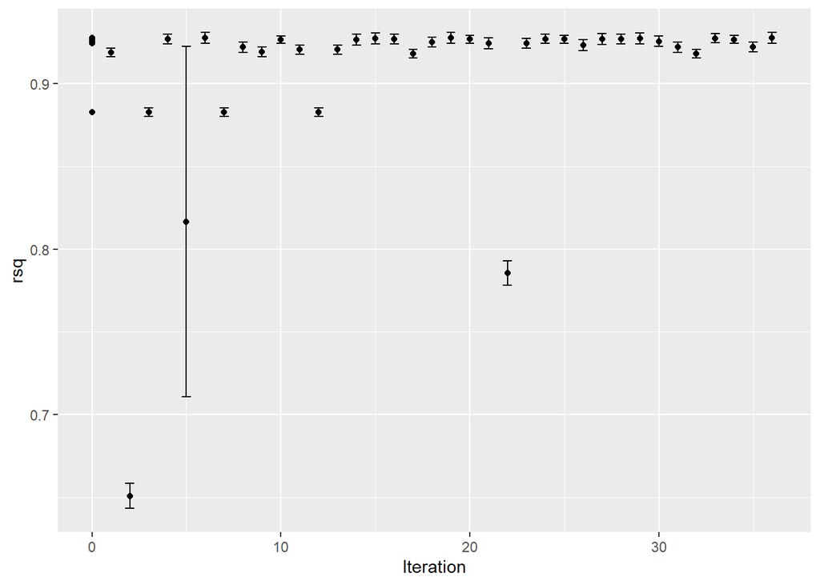

```r
autoplot(SearchResult, type = "performance")
```

There are many parameter combinations with roughly equivalent results

How did the parameters change over iterations?

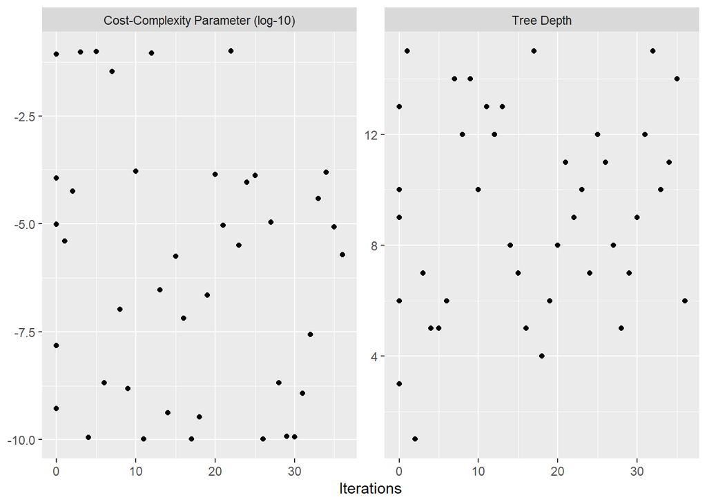

```r
autoplot(SearchResult, type = "parameters") +
  labs(x = "Iterations", y = NULL)
```

## mlr3: Tuners

An overview over available tuners:

```r
as.data.table(mlr_tuners)
```

```
##              key                                           label
## 1:         cmaes Covariance Matrix Adaptation Evolution Strategy
## 2: design_points                                   Design Points
## 3:         gensa                 Generalized Simulated Annealing
## 4:   grid_search                                     Grid Search
## 5:         irace                                 Iterated Racing
## 6:        nloptr                         Non-linear Optimization
## 7: random_search                                   Random Search
##                                   param_classes
## 1:                                     ParamDbl
## 2: ParamLgl,ParamInt,ParamDbl,ParamFct,ParamUty
## 3:                                     ParamDbl
## 4:          ParamLgl,ParamInt,ParamDbl,ParamFct
## 5:          ParamDbl,ParamInt,ParamFct,ParamLgl
## 6:                                     ParamDbl
## 7:          ParamLgl,ParamInt,ParamDbl,ParamFct
##                             properties                packages
## 1:                         single-crit mlr3tuning,bbotk,adagio
## 2: dependencies,single-crit,multi-crit        mlr3tuning,bbotk
## 3:                         single-crit  mlr3tuning,bbotk,GenSA
## 4: dependencies,single-crit,multi-crit              mlr3tuning
## 5:            dependencies,single-crit  mlr3tuning,bbotk,irace
## 6:                         single-crit mlr3tuning,bbotk,nloptr
## 7: dependencies,single-crit,multi-crit        mlr3tuning,bbotk
```

```r
    mlr_tuners$get("random_search")
```

```
## <TunerRandomSearch>: Random Search
## * Parameters: batch_size=1
## * Parameter classes: ParamLgl, ParamInt, ParamDbl, ParamFct
## * Properties: dependencies, single-crit, multi-crit
## * Packages: mlr3tuning, bbotk
```

```r
    tnr("random_search")
```

```
## <TunerRandomSearch>: Random Search
## * Parameters: batch_size=1
## * Parameter classes: ParamLgl, ParamInt, ParamDbl, ParamFct
## * Properties: dependencies, single-crit, multi-crit
## * Packages: mlr3tuning, bbotk
```